# HNSCC UNM Althoff et al_Clinical Analysis

```r
# **PFS by ctDNA at MRD p16(+)**

rm(list=ls())
setwd("~/Downloads")
circ_data <- read.csv("CLIA HNSCC Peddada Clinical Data.csv")
circ_data <- circ_data[circ_data$ctDNA.available=="TRUE",]
circ_data <- circ_data[circ_data$p16.status=="Positive",]
circ_data <- circ_data[circ_data$ctDNA.MRD!="",]
circ_datadf <- as.data.frame(circ_data)

survfit(Surv(time = circ_data$PFS.months, event = circ_data$PFS.Event)~ctDNA.MRD, data = circ_data)
```

```
## Call: survfit(formula = Surv(time = circ_data$PFS.months, event = circ_data$PFS.Event) ~
##     ctDNA.MRD, data = circ_data)
##
##                     n events median 0.95LCL 0.95UCL
## ctDNA.MRD=NEGATIVE 29      2     NA      NA      NA
## ctDNA.MRD=POSITIVE  8      4   22.2    6.01      NA
```

```r
event_summary <- circ_data %>%
  group_by(ctDNA.MRD) %>%
  summarise(
    Total = n(),
    Events = sum(PFS.Event),
    Fraction = Events / n(),
    Percentage = (Events / n()) * 100
  )
print(event_summary)
```

```
## # A tibble: 2 × 5
##   ctDNA.MRD Total Events Fraction Percentage
##   <chr>     <int>  <int>    <dbl>      <dbl>
## 1 NEGATIVE     29      2   0.0690       6.90
## 2 POSITIVE      8      4   0.5         50
```

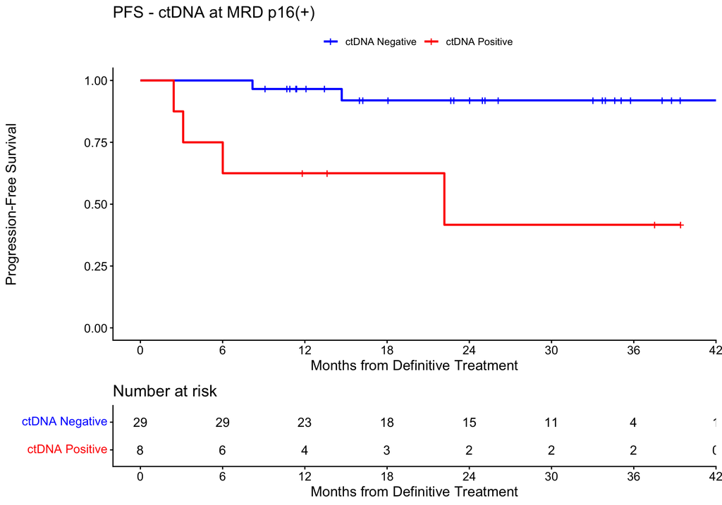

```r
surv_object <-Surv(time = circ_data$PFS.months, event = circ_data$PFS.Event)
KM_curve <- survfit(surv_object ~ ctDNA.MRD, data = circ_data,conf.int=0.95,conf.type="log-log")
ggsurvplot(KM_curve, data = circ_data, pval = FALSE, conf.int = FALSE, risk.table = TRUE, break.time.by=6, palette=c("blue","red"), title="PFS - ctDNA at MRD p16(+)", ylab= "Progression-Free Survival", xlab="Months from Definitive Treatment", legend.labs=c("ctDNA Negative", "ctDNA Positive"), legend.title="")
```

```r
summary(KM_curve, times= c(0, 12, 24, 36))
```

```
## Call: survfit(formula = surv_object ~ ctDNA.MRD, data = circ_data,
##     conf.int = 0.95, conf.type = "log-log")
##
##                 ctDNA.MRD=NEGATIVE
##  time n.risk n.event survival std.err lower 95% CI upper 95% CI
##     0     29       0    1.000  0.0000        1.000        1.000
##    12     23       1    0.966  0.0339        0.779        0.995
##    24     15       1    0.920  0.0553        0.711        0.980
##    36      4       0    0.920  0.0553        0.711        0.980
##
##                 ctDNA.MRD=POSITIVE
##  time n.risk n.event survival std.err lower 95% CI upper 95% CI
##     0      8       0    1.000   0.000        1.000        1.000
##    12      4       3    0.625   0.171        0.229        0.861
##    24      2       1    0.417   0.205        0.072        0.747
##    36      2       0    0.417   0.205        0.072        0.747
```

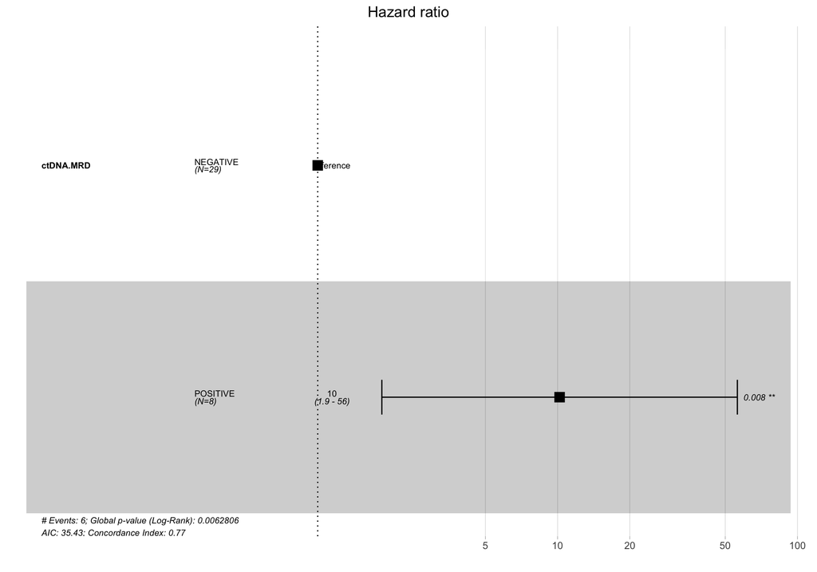

```r
circ_data$ctDNA.MRD <- factor(circ_data$ctDNA.MRD, levels=c("NEGATIVE","POSITIVE"))
cox_fit <- coxph(surv_object ~ ctDNA.MRD, data=circ_data)
ggforest(cox_fit,data = circ_data)
```

```r
summary(cox_fit)
```

```
## Call:
## coxph(formula = surv_object ~ ctDNA.MRD, data = circ_data)
##
##   n= 37, number of events= 6
##
##                      coef exp(coef) se(coef)     z Pr(>|z|)
## ctDNA.MRDPOSITIVE  2.3218   10.1936   0.8706 2.667  0.00766 **
## ---
## Signif. codes:  0 '***' 0.001 '**' 0.01 '*' 0.05 '.' 0.1 ' ' 1
##
##                   exp(coef) exp(-coef) lower .95 upper .95
## ctDNA.MRDPOSITIVE     10.19     0.0981      1.85     56.16
##
## Concordance= 0.767  (se = 0.09 )
## Likelihood ratio test= 7.47  on 1 df,   p=0.006
## Wald test            = 7.11  on 1 df,   p=0.008
## Score (logrank) test = 10.81  on 1 df,   p=0.001
```

```r
cox_fit_summary <- summary(cox_fit)

#Extract values for HR, 95% CI, and p-value
HR <- cox_fit_summary$coefficients[2]
lower_CI <- cox_fit_summary$conf.int[3]
upper_CI <- cox_fit_summary$conf.int[4]
p_value <- cox_fit_summary$coefficients[5]
label_text <- paste0("HR = ", round(HR, 2), " (", round(lower_CI, 2), "-", round(upper_CI, 2), "); p = ", round(p_value, 3))
print(label_text)
```

```
## [1] "HR = 10.19 (1.85-56.16); p = 0.008"
```

```r
circ_data$ctDNA.MRD <- factor(circ_data$ctDNA.MRD, levels = c("NEGATIVE", "POSITIVE"), labels = c("Negative", "Positive"))
circ_data$PFS.Event <- factor(circ_data$PFS.Event, levels = c("FALSE", "TRUE"), labels = c("No Progression", "Progression"))
contingency_table <- table(circ_data$ctDNA.MRD, circ_data$PFS.Event)
chi_square_test <- chisq.test(contingency_table)
print(chi_square_test)
```

```
##
##  Pearson's Chi-squared test with Yates' continuity correction
##
## data:  contingency_table
## X-squared = 5.6953, df = 1, p-value = 0.01701
```

```r
fisher_exact_test <- fisher.test(contingency_table)
print(fisher_exact_test)
```

```
##
##  Fisher's Exact Test for Count Data
##
## data:  contingency_table
## p-value = 0.01294
## alternative hypothesis: true odds ratio is not equal to 1
## 95 percent confidence interval:
##    1.281882 176.017338
## sample estimates:
## odds ratio
##   12.07276
```

```r
print(contingency_table)
```

```
##
##            No Progression Progression
##   Negative             27           2
##   Positive              4           4
```

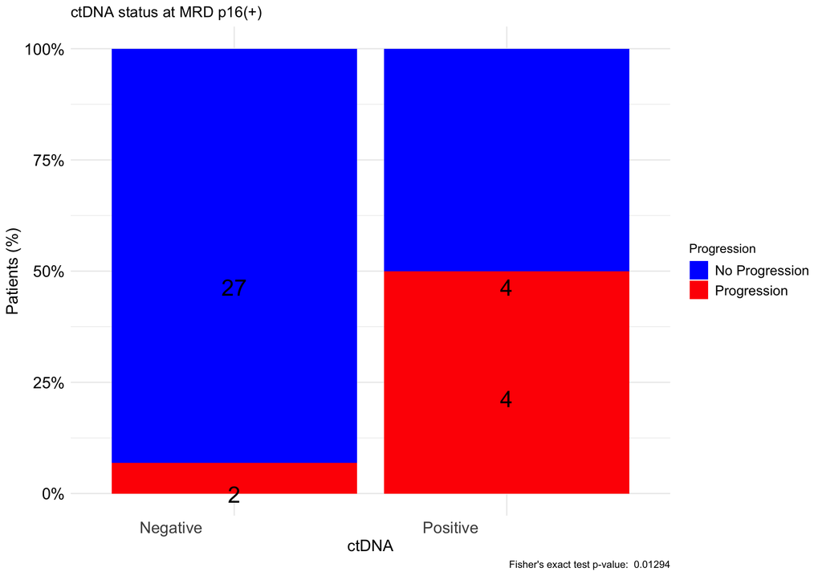

```r
table_df <- as.data.frame(contingency_table)
table_df$Total <- ave(table_df$Freq, table_df$Var1, FUN = sum)
table_df$Percentage <- table_df$Freq / table_df$Total
table_df$MiddlePercentage <- table_df$Percentage / 2
ggplot(table_df, aes(x = Var1, y = Percentage, fill = Var2)) +
  geom_bar(stat = "identity") +
  geom_text(aes(y = MiddlePercentage, label = Freq), position = "stack", color = "black", vjust = 1.5, size = 7) +
  theme_minimal() +
  labs(title = "ctDNA status at MRD p16(+)",
       x = "ctDNA",
       y = "Patients (%)",
       fill = "Progression",
       caption = paste("Fisher's exact test p-value: ", format.pval(fisher_exact_test$p.value))) +
  scale_y_continuous(labels = scales::percent_format()) +
  scale_fill_manual(values = c("No Progression" = "blue", "Progression" = "red")) + # define custom colors
  theme(axis.text.x = element_text(angle = 0, hjust = 1.5, size = 14), # increase x-axis text size
        axis.text.y = element_text(size = 14, color = "black"), # increase y-axis text size
        axis.title.x = element_text(size = 14, color = "black"), # increase x-axis label size
        axis.title.y = element_text(size = 14, color = "black"), # increase y-axis label size
        legend.text = element_text(size = 12, color = "black"))  # increase Progression label size
```

```r
# **PFS by ctDNA at MRD p16(-)**

rm(list=ls())
setwd("~/Downloads")
circ_data <- read.csv("CLIA HNSCC Peddada Clinical Data.csv")
circ_data <- circ_data[circ_data$ctDNA.available=="TRUE",]
circ_data <- circ_data[circ_data$p16.status=="Negative",]
circ_data <- circ_data[circ_data$ctDNA.MRD!="",]
circ_datadf <- as.data.frame(circ_data)

survfit(Surv(time = circ_data$PFS.months, event = circ_data$PFS.Event)~ctDNA.MRD, data = circ_data)
```

```
## Call: survfit(formula = Surv(time = circ_data$PFS.months, event = circ_data$PFS.Event) ~
##     ctDNA.MRD, data = circ_data)
##
##                     n events median 0.95LCL 0.95UCL
## ctDNA.MRD=NEGATIVE 27      7   40.1   40.08      NA
## ctDNA.MRD=POSITIVE  5      4   11.3    4.21      NA
```

```r
event_summary <- circ_data %>%
  group_by(ctDNA.MRD) %>%
  summarise(
    Total = n(),
    Events = sum(PFS.Event),
    Fraction = Events / n(),
    Percentage = (Events / n()) * 100
  )
print(event_summary)
```

```
## # A tibble: 2 × 5
##   ctDNA.MRD Total Events Fraction Percentage
##   <chr>     <int>  <int>    <dbl>      <dbl>
## 1 NEGATIVE     27      7    0.259       25.9
## 2 POSITIVE      5      4    0.8         80
```

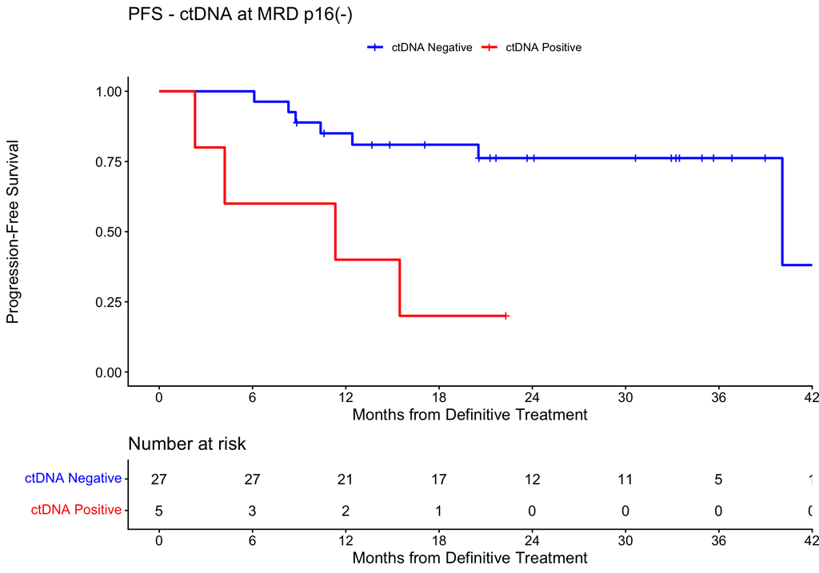

```r
surv_object <-Surv(time = circ_data$PFS.months, event = circ_data$PFS.Event)
KM_curve <- survfit(surv_object ~ ctDNA.MRD, data = circ_data,conf.int=0.95,conf.type="log-log")
ggsurvplot(KM_curve, data = circ_data, pval = FALSE, conf.int = FALSE, risk.table = TRUE, break.time.by=6, palette=c("blue","red"), title="PFS - ctDNA at MRD p16(-)", ylab= "Progression-Free Survival", xlab="Months from Definitive Treatment", legend.labs=c("ctDNA Negative", "ctDNA Positive"), legend.title="")
```

```r
summary(KM_curve, times= c(0, 12, 24, 36))
```

```
## Call: survfit(formula = surv_object ~ ctDNA.MRD, data = circ_data,
##     conf.int = 0.95, conf.type = "log-log")
##
##                 ctDNA.MRD=NEGATIVE
##  time n.risk n.event survival std.err lower 95% CI upper 95% CI
##     0     27       0    1.000  0.0000        1.000        1.000
##    12     21       4    0.850  0.0691        0.649        0.941
##    24     12       2    0.762  0.0858        0.542        0.886
##    36      5       0    0.762  0.0858        0.542        0.886
##
##                 ctDNA.MRD=POSITIVE
##  time n.risk n.event survival std.err lower 95% CI upper 95% CI
##     0      5       0      1.0   0.000        1.000        1.000
##    12      2       3      0.4   0.219        0.052        0.753
```

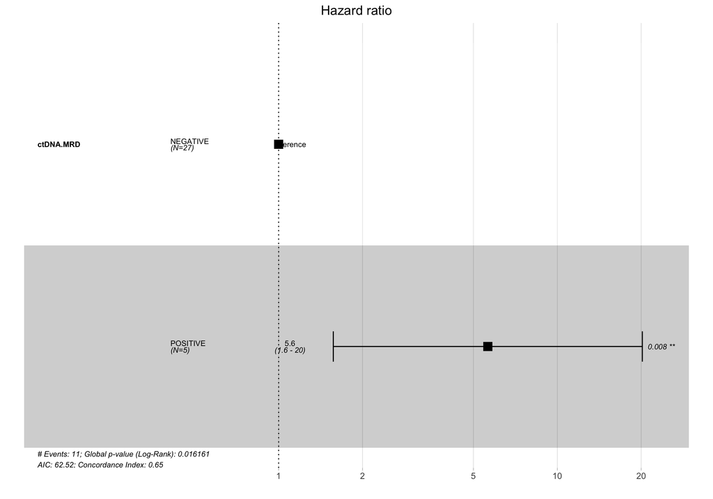

```r
circ_data$ctDNA.MRD <- factor(circ_data$ctDNA.MRD, levels=c("NEGATIVE","POSITIVE"))
cox_fit <- coxph(surv_object ~ ctDNA.MRD, data=circ_data)
ggforest(cox_fit,data = circ_data)
```

```r
summary(cox_fit)
```

```
## Call:
## coxph(formula = surv_object ~ ctDNA.MRD, data = circ_data)
##
##   n= 32, number of events= 11
##
##                     coef exp(coef) se(coef)     z Pr(>|z|)
## ctDNA.MRDPOSITIVE 1.7286    5.6328   0.6515 2.653  0.00797 **
## ---
## Signif. codes:  0 '***' 0.001 '**' 0.01 '*' 0.05 '.' 0.1 ' ' 1
##
##                   exp(coef) exp(-coef) lower .95 upper .95
## ctDNA.MRDPOSITIVE     5.633     0.1775     1.571      20.2
##
## Concordance= 0.655  (se = 0.072 )
## Likelihood ratio test= 5.79  on 1 df,   p=0.02
## Wald test            = 7.04  on 1 df,   p=0.008
## Score (logrank) test = 8.93  on 1 df,   p=0.003
```

```r
cox_fit_summary <- summary(cox_fit)

#Extract values for HR, 95% CI, and p-value
HR <- cox_fit_summary$coefficients[2]
lower_CI <- cox_fit_summary$conf.int[3]
upper_CI <- cox_fit_summary$conf.int[4]
p_value <- cox_fit_summary$coefficients[5]
label_text <- paste0("HR = ", round(HR, 2), " (", round(lower_CI, 2), "-", round(upper_CI, 2), "); p = ", round(p_value, 3))
print(label_text)
```

```
## [1] "HR = 5.63 (1.57-20.2); p = 0.008"
```

```r
circ_data$ctDNA.MRD <- factor(circ_data$ctDNA.MRD, levels = c("NEGATIVE", "POSITIVE"), labels = c("Negative", "Positive"))
circ_data$PFS.Event <- factor(circ_data$PFS.Event, levels = c("FALSE", "TRUE"), labels = c("No Progression", "Progression"))
contingency_table <- table(circ_data$ctDNA.MRD, circ_data$PFS.Event)
chi_square_test <- chisq.test(contingency_table)
print(chi_square_test)
```

```
##
##  Pearson's Chi-squared test with Yates' continuity correction
##
## data:  contingency_table
## X-squared = 3.3339, df = 1, p-value = 0.06787
```

```r
fisher_exact_test <- fisher.test(contingency_table)
print(fisher_exact_test)
```

```
##
##  Fisher's Exact Test for Count Data
##
## data:  contingency_table
## p-value = 0.03671
## alternative hypothesis: true odds ratio is not equal to 1
## 95 percent confidence interval:
##    0.8530265 587.6303377
## sample estimates:
## odds ratio
##   10.45501
```

```r
print(contingency_table)
```

```
##
##            No Progression Progression
##   Negative             20           7
##   Positive              1           4
```

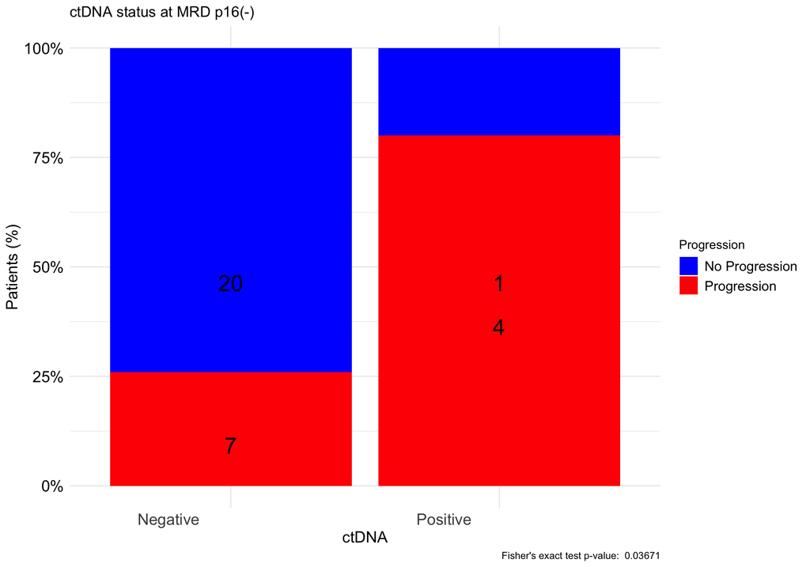

```r
table_df <- as.data.frame(contingency_table)
table_df$Total <- ave(table_df$Freq, table_df$Var1, FUN = sum)
table_df$Percentage <- table_df$Freq / table_df$Total
table_df$MiddlePercentage <- table_df$Percentage / 2
ggplot(table_df, aes(x = Var1, y = Percentage, fill = Var2)) +
  geom_bar(stat = "identity") +
  geom_text(aes(y = MiddlePercentage, label = Freq), position = "stack", color = "black", vjust = 1.5, size = 7) +
  theme_minimal() +
  labs(title = "ctDNA status at MRD p16(-)",
       x = "ctDNA",
       y = "Patients (%)",
       fill = "Progression",
       caption = paste("Fisher's exact test p-value: ", format.pval(fisher_exact_test$p.value))) +
  scale_y_continuous(labels = scales::percent_format()) +
  scale_fill_manual(values = c("No Progression" = "blue", "Progression" = "red")) + # define custom colors
  theme(axis.text.x = element_text(angle = 0, hjust = 1.5, size = 14), # increase x-axis text size
        axis.text.y = element_text(size = 14, color = "black"), # increase y-axis text size
        axis.title.x = element_text(size = 14, color = "black"), # increase x-axis label size
        axis.title.y = element_text(size = 14, color = "black"), # increase y-axis label size
        legend.text = element_text(size = 12, color = "black"))  # increase Progression label size
```

```r
# **PFS by ctDNA at MRD chemoRT**

rm(list=ls())
setwd("~/Downloads")
circ_data <- read.csv("CLIA HNSCC Peddada Clinical Data.csv")
circ_data <- circ_data[circ_data$ctDNA.available=="TRUE",]
circ_data <- circ_data[circ_data$ctDNA.MRD!="",]
circ_data <- circ_data[circ_data$MRD.Group=="ChemoRT",]
circ_datadf <- as.data.frame(circ_data)

survfit(Surv(time = circ_data$PFS.months, event = circ_data$PFS.Event)~ctDNA.MRD, data = circ_data)
```

```
## Call: survfit(formula = Surv(time = circ_data$PFS.months, event = circ_data$PFS.Event) ~
##     ctDNA.MRD, data = circ_data)
##
##                     n events median 0.95LCL 0.95UCL
## ctDNA.MRD=NEGATIVE 42      6     NA   40.08      NA
## ctDNA.MRD=POSITIVE  6      5   8.67    3.12      NA
```

```r
event_summary <- circ_data %>%
  group_by(ctDNA.MRD) %>%
  summarise(
    Total = n(),
    Events = sum(PFS.Event),
    Fraction = Events / n(),
    Percentage = (Events / n()) * 100
  )
print(event_summary)
```

```
## # A tibble: 2 × 5
##   ctDNA.MRD Total Events Fraction Percentage
##   <chr>     <int>  <int>    <dbl>      <dbl>
## 1 NEGATIVE     42      6    0.143       14.3
## 2 POSITIVE      6      5    0.833       83.3
```

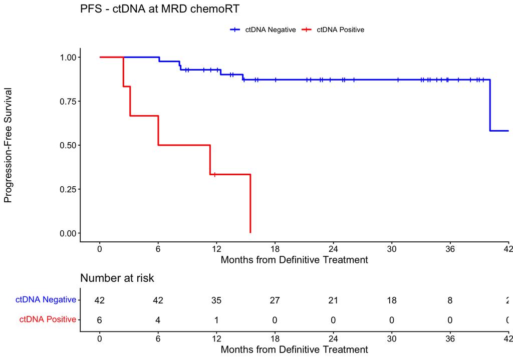

```r
surv_object <-Surv(time = circ_data$PFS.months, event = circ_data$PFS.Event)
KM_curve <- survfit(surv_object ~ ctDNA.MRD, data = circ_data,conf.int=0.95,conf.type="log-log")
ggsurvplot(KM_curve, data = circ_data, pval = FALSE, conf.int = FALSE, risk.table = TRUE, break.time.by=6, palette=c("blue","red"), title="PFS - ctDNA at MRD chemoRT", ylab= "Progression-Free Survival", xlab="Months from Definitive Treatment", legend.labs=c("ctDNA Negative", "ctDNA Positive"), legend.title="")
```

```r
summary(KM_curve, times= c(0, 12, 24, 36))
```

```
## Call: survfit(formula = surv_object ~ ctDNA.MRD, data = circ_data,
##     conf.int = 0.95, conf.type = "log-log")
##
##                 ctDNA.MRD=NEGATIVE
##  time n.risk n.event survival std.err lower 95% CI upper 95% CI
##     0     42       0    1.000  0.0000        1.000        1.000
##    12     35       3    0.929  0.0397        0.795        0.976
##    24     21       2    0.872  0.0538        0.718        0.945
##    36      8       0    0.872  0.0538        0.718        0.945
##
##                 ctDNA.MRD=POSITIVE
##  time n.risk n.event survival std.err lower 95% CI upper 95% CI
##     0      6       0    1.000   0.000       1.0000        1.000
##    12      1       4    0.333   0.192       0.0461        0.676
```

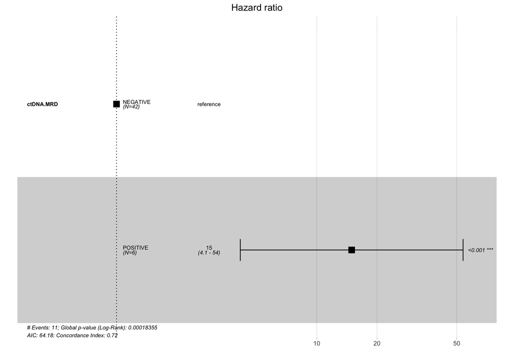

```r
circ_data$ctDNA.MRD <- factor(circ_data$ctDNA.MRD, levels=c("NEGATIVE","POSITIVE"))
cox_fit <- coxph(surv_object ~ ctDNA.MRD, data=circ_data)
ggforest(cox_fit,data = circ_data)
```

```r
summary(cox_fit)
```

```
## Call:
## coxph(formula = surv_object ~ ctDNA.MRD, data = circ_data)
##
##   n= 48, number of events= 11
##
##                      coef exp(coef) se(coef)     z Pr(>|z|)
## ctDNA.MRDPOSITIVE  2.7039   14.9382   0.6535 4.137 3.51e-05 ***
## ---
## Signif. codes:  0 '***' 0.001 '**' 0.01 '*' 0.05 '.' 0.1 ' ' 1
##
##                   exp(coef) exp(-coef) lower .95 upper .95
## ctDNA.MRDPOSITIVE     14.94    0.06694      4.15     53.77
##
## Concordance= 0.724  (se = 0.072 )
## Likelihood ratio test= 13.99  on 1 df,   p=2e-04
## Wald test            = 17.12  on 1 df,   p=4e-05
## Score (logrank) test = 29.18  on 1 df,   p=7e-08
```

```r
cox_fit_summary <- summary(cox_fit)

#Extract values for HR, 95% CI, and p-value
HR <- cox_fit_summary$coefficients[2]
lower_CI <- cox_fit_summary$conf.int[3]
upper_CI <- cox_fit_summary$conf.int[4]
p_value <- cox_fit_summary$coefficients[5]
label_text <- paste0("HR = ", round(HR, 2), " (", round(lower_CI, 2), "-", round(upper_CI, 2), "); p = ", round(p_value, 3))
print(label_text)
```

```
## [1] "HR = 14.94 (4.15-53.77); p = 0"
```

```r
# **OS by ctDNA at MRD chemoRT**

rm(list=ls())
setwd("~/Downloads")
circ_data <- read.csv("CLIA HNSCC Peddada Clinical Data.csv")
circ_data <- circ_data[circ_data$ctDNA.available=="TRUE",]
circ_data <- circ_data[circ_data$ctDNA.MRD!="",]
circ_data <- circ_data[circ_data$MRD.Group=="ChemoRT",]
circ_datadf <- as.data.frame(circ_data)

survfit(Surv(time = circ_data$OS.months, event = circ_data$OS.Event)~ctDNA.MRD, data = circ_data)
```

```
## Call: survfit(formula = Surv(time = circ_data$OS.months, event = circ_data$OS.Event) ~
##     ctDNA.MRD, data = circ_data)
##
##                     n events median 0.95LCL 0.95UCL
## ctDNA.MRD=NEGATIVE 42      1     NA      NA      NA
## ctDNA.MRD=POSITIVE  6      2     NA    12.3      NA
```

```r
event_summary <- circ_data %>%
  group_by(ctDNA.MRD) %>%
  summarise(
    Total = n(),
    Events = sum(OS.Event),
    Fraction = Events / n(),
    Percentage = (Events / n()) * 100
  )
print(event_summary)
```

```
## # A tibble: 2 × 5
##   ctDNA.MRD Total Events Fraction Percentage
##   <chr>     <int>  <int>    <dbl>      <dbl>
## 1 NEGATIVE     42      1   0.0238       2.38
## 2 POSITIVE      6      2   0.333       33.3
```

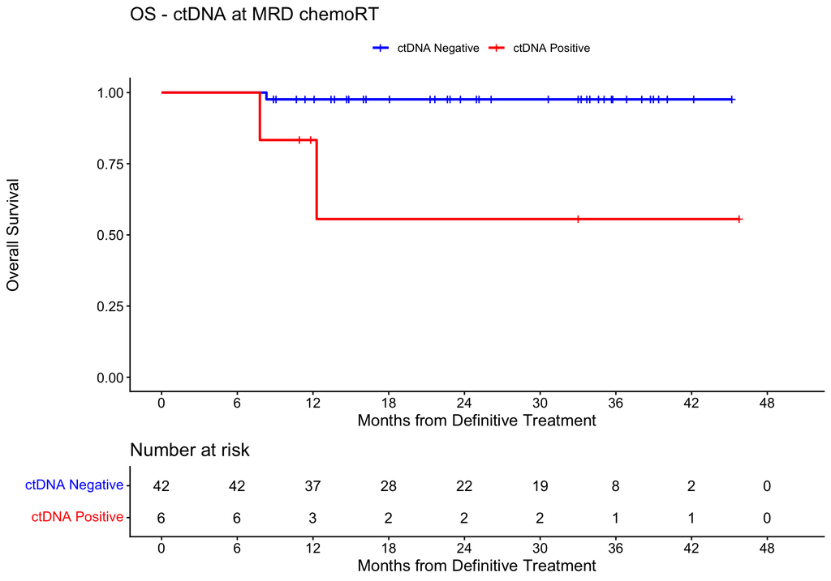

```r
surv_object <-Surv(time = circ_data$OS.months, event = circ_data$OS.Event)
KM_curve <- survfit(surv_object ~ ctDNA.MRD, data = circ_data,conf.int=0.95,conf.type="log-log")
ggsurvplot(KM_curve, data = circ_data, pval = FALSE, conf.int = FALSE, risk.table = TRUE, break.time.by=6, palette=c("blue","red"), title="OS - ctDNA at MRD chemoRT", ylab= "Overall Survival", xlab="Months from Definitive Treatment", legend.labs=c("ctDNA Negative", "ctDNA Positive"), legend.title="")
```

```r
summary(KM_curve, times= c(12, 24, 36))
```

```
## Call: survfit(formula = surv_object ~ ctDNA.MRD, data = circ_data,
##     conf.int = 0.95, conf.type = "log-log")
##
##                 ctDNA.MRD=NEGATIVE
##  time n.risk n.event survival std.err lower 95% CI upper 95% CI
##    12     37       1    0.976  0.0235        0.843        0.997
##    24     22       0    0.976  0.0235        0.843        0.997
##    36      8       0    0.976  0.0235        0.843        0.997
##
##                 ctDNA.MRD=POSITIVE
##  time n.risk n.event survival std.err lower 95% CI upper 95% CI
##    12      3       1    0.833   0.152       0.2731        0.975
##    24      2       1    0.556   0.248       0.0734        0.876
##    36      1       0    0.556   0.248       0.0734        0.876
```

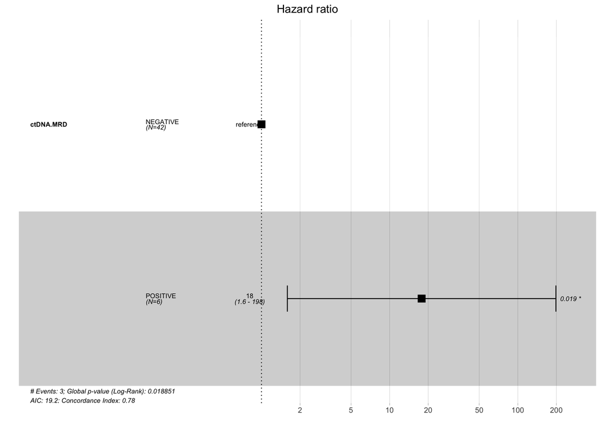

```r
circ_data$ctDNA.MRD <- factor(circ_data$ctDNA.MRD, levels=c("NEGATIVE","POSITIVE"))
cox_fit <- coxph(surv_object ~ ctDNA.MRD, data=circ_data)
ggforest(cox_fit,data = circ_data)
```

```r
summary(cox_fit)
```

```
## Call:
## coxph(formula = surv_object ~ ctDNA.MRD, data = circ_data)
##
##   n= 48, number of events= 3
##
##                     coef exp(coef) se(coef)     z Pr(>|z|)
## ctDNA.MRDPOSITIVE  2.877    17.768    1.231 2.338   0.0194 *
## ---
## Signif. codes:  0 '***' 0.001 '**' 0.01 '*' 0.05 '.' 0.1 ' ' 1
##
##                   exp(coef) exp(-coef) lower .95 upper .95
## ctDNA.MRDPOSITIVE     17.77    0.05628     1.592     198.3
##
## Concordance= 0.777  (se = 0.141 )
## Likelihood ratio test= 5.52  on 1 df,   p=0.02
## Wald test            = 5.46  on 1 df,   p=0.02
## Score (logrank) test = 10.3  on 1 df,   p=0.001
```

```r
cox_fit_summary <- summary(cox_fit)

#Extract values for HR, 95% CI, and p-value
HR <- cox_fit_summary$coefficients[2]
lower_CI <- cox_fit_summary$conf.int[3]
upper_CI <- cox_fit_summary$conf.int[4]
p_value <- cox_fit_summary$coefficients[5]
label_text <- paste0("HR = ", round(HR, 2), " (", round(lower_CI, 2), "-", round(upper_CI, 2), "); p = ", round(p_value, 3))
print(label_text)
```

```
## [1] "HR = 17.77 (1.59-198.34); p = 0.019"
```

```r
# **PFS by ctDNA at MRD post-surgery**

rm(list=ls())
setwd("~/Downloads")
circ_data <- read.csv("CLIA HNSCC Peddada Clinical Data.csv")
circ_data <- circ_data[circ_data$ctDNA.available=="TRUE",]
circ_data <- circ_data[circ_data$ctDNA.MRD!="",]
circ_data <- circ_data[circ_data$MRD.Group=="Surgery",]
circ_datadf <- as.data.frame(circ_data)

survfit(Surv(time = circ_data$PFS.months, event = circ_data$PFS.Event)~ctDNA.MRD, data = circ_data)
```

```
## Call: survfit(formula = Surv(time = circ_data$PFS.months, event = circ_data$PFS.Event) ~
##     ctDNA.MRD, data = circ_data)
##
##                     n events median 0.95LCL 0.95UCL
## ctDNA.MRD=NEGATIVE 14      3     NA      NA      NA
## ctDNA.MRD=POSITIVE  4      1     NA    4.21      NA
```

```r
event_summary <- circ_data %>%
  group_by(ctDNA.MRD) %>%
  summarise(
    Total = n(),
    Events = sum(PFS.Event),
    Fraction = Events / n(),
    Percentage = (Events / n()) * 100
  )
print(event_summary)
```

```
## # A tibble: 2 × 5
##   ctDNA.MRD Total Events Fraction Percentage
##   <chr>     <int>  <int>    <dbl>      <dbl>
## 1 NEGATIVE     14      3    0.214       21.4
## 2 POSITIVE      4      1    0.25        25
```

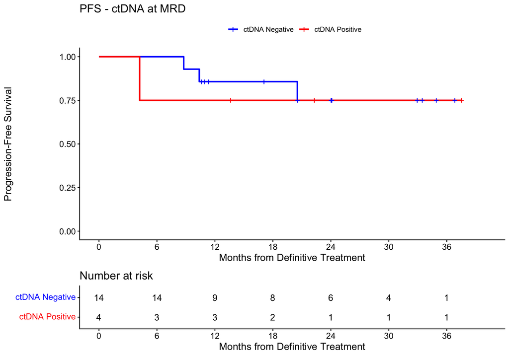

```r
surv_object <-Surv(time = circ_data$PFS.months, event = circ_data$PFS.Event)
KM_curve <- survfit(surv_object ~ ctDNA.MRD, data = circ_data,conf.int=0.95,conf.type="log-log")
ggsurvplot(KM_curve, data = circ_data, pval = FALSE, conf.int = FALSE, risk.table = TRUE, break.time.by=6, palette=c("blue","red"), title="PFS - ctDNA at MRD", ylab= "Progression-Free Survival", xlab="Months from Definitive Treatment", legend.labs=c("ctDNA Negative", "ctDNA Positive"), legend.title="")
```

```r
summary(KM_curve, times= c(0, 12, 24, 36))
```

```
## Call: survfit(formula = surv_object ~ ctDNA.MRD, data = circ_data,
##     conf.int = 0.95, conf.type = "log-log")
##
##                 ctDNA.MRD=NEGATIVE
##  time n.risk n.event survival std.err lower 95% CI upper 95% CI
##     0     14       0    1.000  0.0000        1.000        1.000
##    12      9       2    0.857  0.0935        0.539        0.962
##    24      6       1    0.750  0.1294        0.394        0.915
##    36      1       0    0.750  0.1294        0.394        0.915
##
##                 ctDNA.MRD=POSITIVE
##  time n.risk n.event survival std.err lower 95% CI upper 95% CI
##     0      4       0     1.00   0.000        1.000        1.000
##    12      3       1     0.75   0.217        0.128        0.961
##    24      1       0     0.75   0.217        0.128        0.961
##    36      1       0     0.75   0.217        0.128        0.961
```

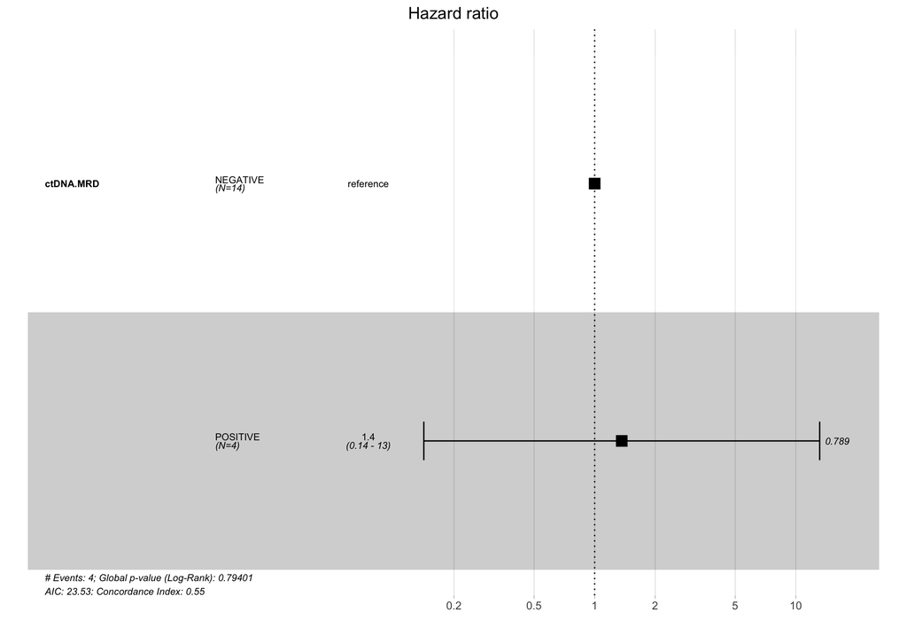

```r
circ_data$ctDNA.MRD <- factor(circ_data$ctDNA.MRD, levels=c("NEGATIVE","POSITIVE"))
cox_fit <- coxph(surv_object ~ ctDNA.MRD, data=circ_data)
ggforest(cox_fit,data = circ_data)
```

```r
summary(cox_fit)
```

```
## Call:
## coxph(formula = surv_object ~ ctDNA.MRD, data = circ_data)
##
##   n= 18, number of events= 4
##
##                    coef exp(coef) se(coef)     z Pr(>|z|)
## ctDNA.MRDPOSITIVE 0.310     1.363    1.156 0.268    0.789
##
##                   exp(coef) exp(-coef) lower .95 upper .95
## ctDNA.MRDPOSITIVE     1.363     0.7334    0.1415     13.14
##
## Concordance= 0.553  (se = 0.129 )
## Likelihood ratio test= 0.07  on 1 df,   p=0.8
## Wald test            = 0.07  on 1 df,   p=0.8
## Score (logrank) test = 0.07  on 1 df,   p=0.8
```

```r
cox_fit_summary <- summary(cox_fit)

#Extract values for HR, 95% CI, and p-value
HR <- cox_fit_summary$coefficients[2]
lower_CI <- cox_fit_summary$conf.int[3]
upper_CI <- cox_fit_summary$conf.int[4]
p_value <- cox_fit_summary$coefficients[5]
label_text <- paste0("HR = ", round(HR, 2), " (", round(lower_CI, 2), "-", round(upper_CI, 2), "); p = ", round(p_value, 3))
print(label_text)
```

```
## [1] "HR = 1.36 (0.14-13.14); p = 0.789"
```

```r
median_fu <- survfit(Surv(time = circ_data$OS.months, event = 1 - circ_data$OS.Event) ~ 1, data = circ_data)
print(median_fu)
```

```
## Call: survfit(formula = Surv(time = circ_data$OS.months, event = 1 -
##     circ_data$OS.Event) ~ 1, data = circ_data)
##
##       n events median 0.95LCL 0.95UCL
## [1,] 18     17     24    17.4    36.4
```

# 8. Figure 5

Kaplan-Meier estimates of outcomes stratified by ctDNA in surveillance and role of ctDNA dynamics.

- **ctDNA status in post-definitive treatment surveillance** — PFS and OS estimates, time-dependent and Multivariate analysis.
- **MRD dynamics in surveillance** — Serial ctDNA measurements for patients grouped based on ctDNA status in the post-definitive treatment surveillance window,
- **Lead time calculations and ctDNA velocity** — Lead time in months is calculated between molecular recurrence (ctDNA positivity, indicated by the blue dot) and clinical recurrence (radiographic imaging positive, indicated by the red dot) during the post-definitive treatment surveillance window (N = 22). Linear regression lines of ctDNA levels at the time of clinical recurrence.

```r
# **PFS by ctDNA status at surveillance**

rm(list=ls())
setwd("~/Downloads")
circ_data <- read.csv("CLIA HNSCC Peddada Clinical Data.csv")
circ_data <- circ_data[circ_data$ctDNA.available=="TRUE",]
circ_data <- circ_data[circ_data$ctDNA.Surveillance!="",]
circ_datadf <- as.data.frame(circ_data)

survfit(Surv(time = circ_data$PFS.months, event = circ_data$PFS.Event)~ctDNA.Surveillance, data = circ_data)
```

```
## Call: survfit(formula = Surv(time = circ_data$PFS.months, event = circ_data$PFS.Event) ~
##     ctDNA.Surveillance, data = circ_data)
##
##                              n events median 0.95LCL 0.95UCL
## ctDNA.Surveillance=NEGATIVE 55      2     NA      NA      NA
## ctDNA.Surveillance=POSITIVE 24     22     12    8.77    20.5
```

```r
event_summary <- circ_data %>%
  group_by(ctDNA.Surveillance) %>%
  summarise(
    Total = n(),
    Events = sum(PFS.Event),
    Fraction = Events / n(),
    Percentage = (Events / n()) * 100
  )
print(event_summary)
```

```
## # A tibble: 2 × 5
##   ctDNA.Surveillance Total Events Fraction Percentage
##   <chr>              <int>  <int>    <dbl>      <dbl>
## 1 NEGATIVE              55      2   0.0364       3.64
## 2 POSITIVE              24     22   0.917       91.7
```

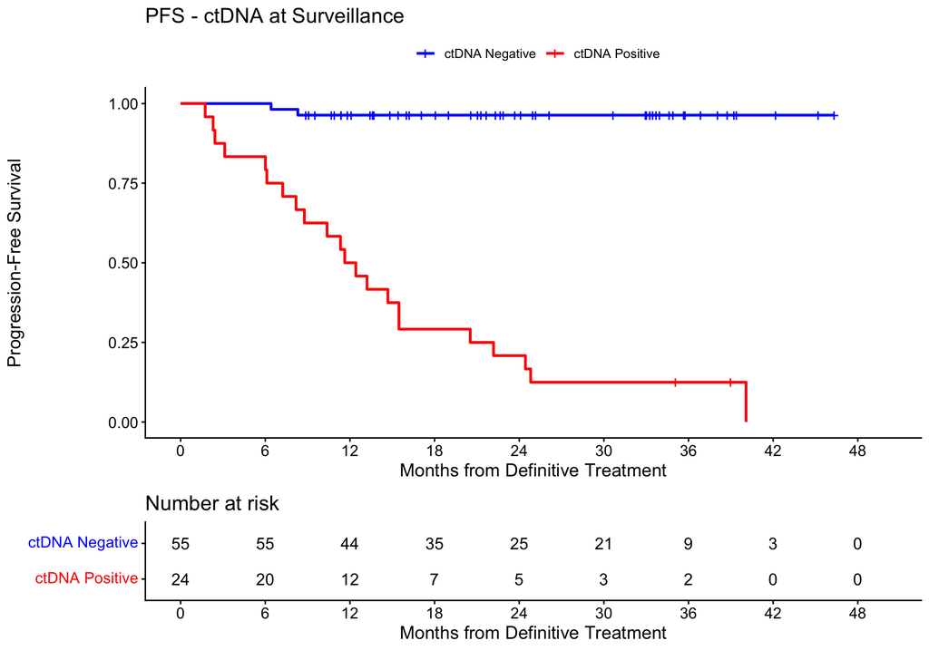

```r
surv_object <-Surv(time = circ_data$PFS.months, event = circ_data$PFS.Event)
KM_curve <- survfit(surv_object ~ ctDNA.Surveillance, data = circ_data,conf.int=0.95,conf.type="log-log")
ggsurvplot(KM_curve, data = circ_data, pval = FALSE, conf.int = FALSE, risk.table = TRUE, break.time.by=6, palette=c("blue","red"), title="PFS - ctDNA at Surveillance", ylab= "Progression-Free Survival", xlab="Months from Definitive Treatment", legend.labs=c("ctDNA Negative", "ctDNA Positive"), legend.title="")
```

```r
summary(KM_curve, times= c(0, 12, 24, 36))
```

```
## Call: survfit(formula = surv_object ~ ctDNA.Surveillance, data = circ_data,
##     conf.int = 0.95, conf.type = "log-log")
##
##                 ctDNA.Surveillance=NEGATIVE
##  time n.risk n.event survival std.err lower 95% CI upper 95% CI
##     0     55       0    1.000  0.0000        1.000        1.000
##    12     44       2    0.964  0.0252        0.862        0.991
##    24     25       0    0.964  0.0252        0.862        0.991
##    36      9       0    0.964  0.0252        0.862        0.991
##
##                 ctDNA.Surveillance=POSITIVE
##  time n.risk n.event survival std.err lower 95% CI upper 95% CI
##     0     24       0    1.000  0.0000       1.0000        1.000
##    12     12      12    0.500  0.1021       0.2910        0.678
##    24      5       7    0.208  0.0829       0.0759        0.385
##    36      2       2    0.125  0.0675       0.0314        0.287
```

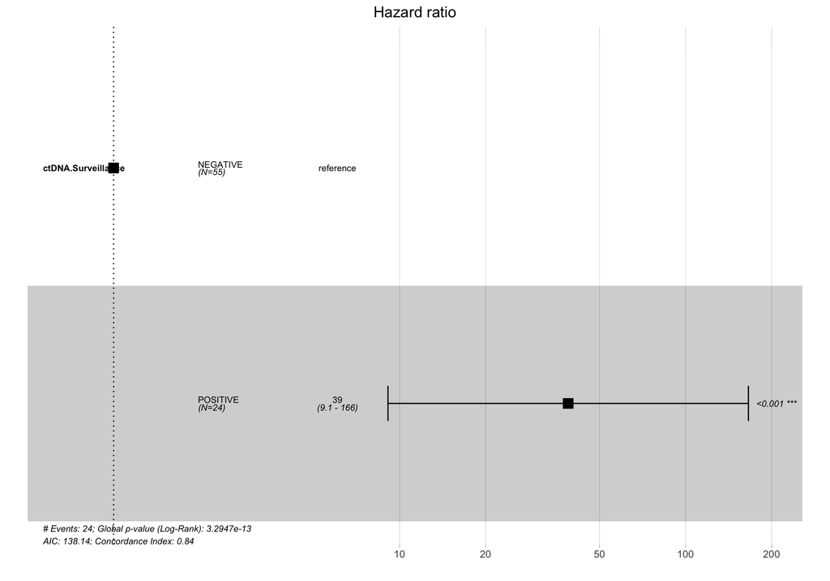

```r
circ_data$ctDNA.Surveillance <- factor(circ_data$ctDNA.Surveillance, levels=c("NEGATIVE","POSITIVE"))
cox_fit <- coxph(surv_object ~ ctDNA.Surveillance, data=circ_data)
ggforest(cox_fit,data = circ_data)
```

```r
summary(cox_fit)
```

```
## Call:
## coxph(formula = surv_object ~ ctDNA.Surveillance, data = circ_data)
##
##   n= 79, number of events= 24
##
##                               coef exp(coef) se(coef)     z Pr(>|z|)
## ctDNA.SurveillancePOSITIVE  3.6602   38.8674   0.7404 4.944 7.67e-07 ***
## ---
## Signif. codes:  0 '***' 0.001 '**' 0.01 '*' 0.05 '.' 0.1 ' ' 1
##
##                            exp(coef) exp(-coef) lower .95 upper .95
## ctDNA.SurveillancePOSITIVE     38.87    0.02573     9.107     165.9
##
## Concordance= 0.836  (se = 0.038 )
## Likelihood ratio test= 53.02  on 1 df,   p=3e-13
## Wald test            = 24.44  on 1 df,   p=8e-07
## Score (logrank) test = 65.38  on 1 df,   p=6e-16
```

```r
cox_fit_summary <- summary(cox_fit)

#Extract values for HR, 95% CI, and p-value
HR <- cox_fit_summary$coefficients[2]
lower_CI <- cox_fit_summary$conf.int[3]
upper_CI <- cox_fit_summary$conf.int[4]
p_value <- cox_fit_summary$coefficients[5]
label_text <- paste0("HR = ", round(HR, 2), " (", round(lower_CI, 2), "-", round(upper_CI, 2), "); p = ", round(p_value, 3))
print(label_text)
```

```
## [1] "HR = 38.87 (9.11-165.88); p = 0"
```

```r
circ_data$ctDNA.Surveillance <- factor(circ_data$ctDNA.Surveillance, levels = c("NEGATIVE", "POSITIVE"), labels = c("Negative", "Positive"))
circ_data$PFS.Event <- factor(circ_data$PFS.Event, levels = c("FALSE", "TRUE"), labels = c("No Progression", "Progression"))
contingency_table <- table(circ_data$ctDNA.Surveillance, circ_data$PFS.Event)
chi_square_test <- chisq.test(contingency_table)
print(chi_square_test)
```

```
##
##  Pearson's Chi-squared test with Yates' continuity correction
##
## data:  contingency_table
## X-squared = 57.128, df = 1, p-value = 4.083e-14
```

```r
fisher_exact_test <- fisher.test(contingency_table)
print(fisher_exact_test)
```

```
##
##  Fisher's Exact Test for Count Data
##
## data:  contingency_table
## p-value = 3.621e-15
## alternative hypothesis: true odds ratio is not equal to 1
## 95 percent confidence interval:
##    31.4353 3628.7424
## sample estimates:
## odds ratio
##   229.7243
```

```r
print(contingency_table)
```

```
##
##            No Progression Progression
##   Negative             53           2
##   Positive              2          22
```

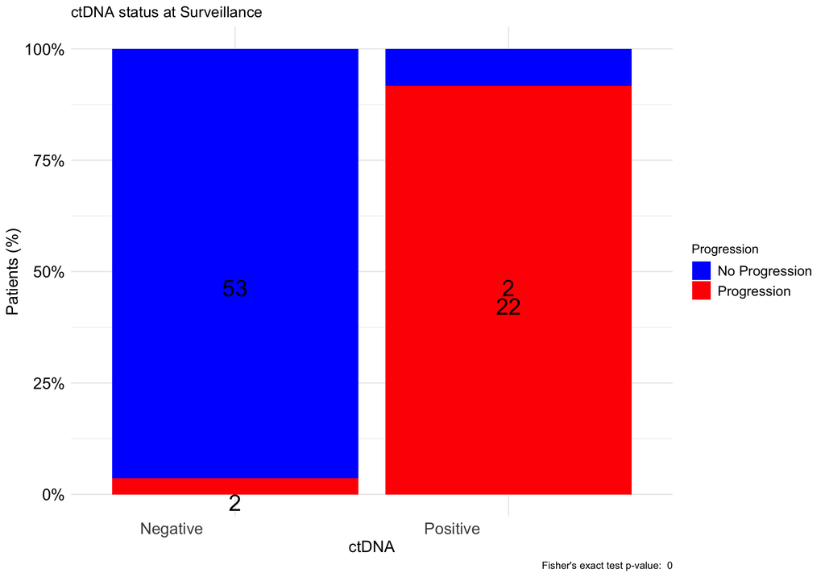

```r
table_df <- as.data.frame(contingency_table)
table_df$Total <- ave(table_df$Freq, table_df$Var1, FUN = sum)
table_df$Percentage <- table_df$Freq / table_df$Total
table_df$MiddlePercentage <- table_df$Percentage / 2
ggplot(table_df, aes(x = Var1, y = Percentage, fill = Var2)) +
  geom_bar(stat = "identity") +
  geom_text(aes(y = MiddlePercentage, label = Freq), position = "stack", color = "black", vjust = 1.5, size = 7) +
  theme_minimal() +
  labs(title = "ctDNA status at Surveillance",
       x = "ctDNA",
       y = "Patients (%)",
       fill = "Progression",
       caption = paste("Fisher's exact test p-value: ", format.pval(fisher_exact_test$p.value))) +
  scale_y_continuous(labels = scales::percent_format()) +
  scale_fill_manual(values = c("No Progression" = "blue", "Progression" = "red")) + # define custom colors
  theme(axis.text.x = element_text(angle = 0, hjust = 1.5, size = 14), # increase x-axis text size
        axis.text.y = element_text(size = 14, color = "black"), # increase y-axis text size
        axis.title.x = element_text(size = 14, color = "black"), # increase x-axis label size
        axis.title.y = element_text(size = 14, color = "black"), # increase y-axis label size
        legend.text = element_text(size = 12, color = "black"))  # increase Progression label size
```

```r
# **OS by ctDNA status at surveillance**

rm(list=ls())
setwd("~/Downloads")
circ_data <- read.csv("CLIA HNSCC Peddada Clinical Data.csv")
circ_data <- circ_data[circ_data$ctDNA.available=="TRUE",]
circ_data <- circ_data[circ_data$ctDNA.Surveillance!="",]
circ_datadf <- as.data.frame(circ_data)

survfit(Surv(time = circ_data$OS.months, event = circ_data$OS.Event)~ctDNA.Surveillance, data = circ_data)
```

```
## Call: survfit(formula = Surv(time = circ_data$OS.months, event = circ_data$OS.Event) ~
##     ctDNA.Surveillance, data = circ_data)
##
##                              n events median 0.95LCL 0.95UCL
## ctDNA.Surveillance=NEGATIVE 55      1     NA      NA      NA
## ctDNA.Surveillance=POSITIVE 24      6     NA      NA      NA
```

```r
event_summary <- circ_data %>%
  group_by(ctDNA.Surveillance) %>%
  summarise(
    Total = n(),
    Events = sum(OS.Event),
    Fraction = Events / n(),
    Percentage = (Events / n()) * 100
  )
print(event_summary)
```

```
## # A tibble: 2 × 5
##   ctDNA.Surveillance Total Events Fraction Percentage
##   <chr>              <int>  <int>    <dbl>      <dbl>
## 1 NEGATIVE              55      1   0.0182       1.82
## 2 POSITIVE              24      6   0.25        25
```

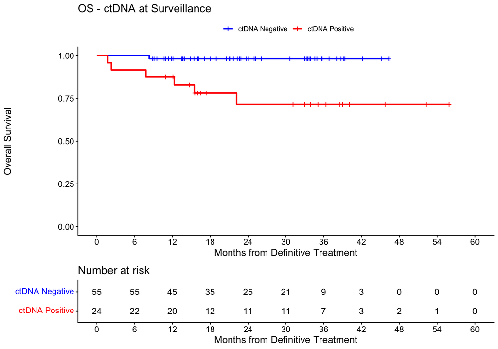

```r
surv_object <-Surv(time = circ_data$OS.months, event = circ_data$OS.Event)
KM_curve <- survfit(surv_object ~ ctDNA.Surveillance, data = circ_data,conf.int=0.95,conf.type="log-log")
ggsurvplot(KM_curve, data = circ_data, pval = FALSE, conf.int = FALSE, risk.table = TRUE, break.time.by=6, palette=c("blue","red"), title="OS - ctDNA at Surveillance", ylab= "Overall Survival", xlab="Months from Definitive Treatment", legend.labs=c("ctDNA Negative", "ctDNA Positive"), legend.title="")
```

```r
summary(KM_curve, times= c(0, 12, 24, 36))
```

```
## Call: survfit(formula = surv_object ~ ctDNA.Surveillance, data = circ_data,
##     conf.int = 0.95, conf.type = "log-log")
##
##                 ctDNA.Surveillance=NEGATIVE
##  time n.risk n.event survival std.err lower 95% CI upper 95% CI
##     0     55       0    1.000   0.000        1.000        1.000
##    12     45       1    0.982   0.018        0.878        0.997
##    24     25       0    0.982   0.018        0.878        0.997
##    36      9       0    0.982   0.018        0.878        0.997
##
##                 ctDNA.Surveillance=POSITIVE
##  time n.risk n.event survival std.err lower 95% CI upper 95% CI
##     0     24       0    1.000  0.0000        1.000        1.000
##    12     20       3    0.875  0.0675        0.661        0.958
##    24     11       3    0.715  0.1015        0.464        0.864
##    36      7       0    0.715  0.1015        0.464        0.864
```

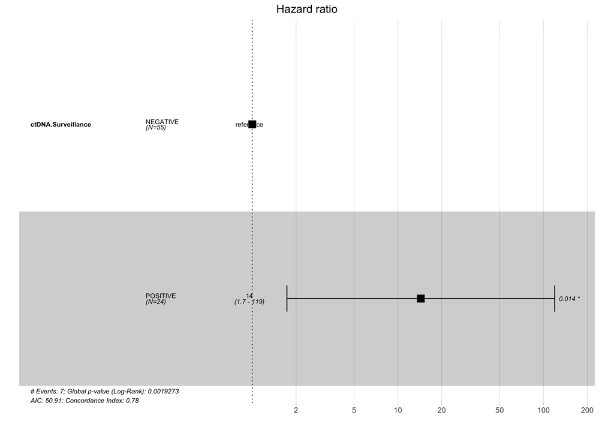

```r
circ_data$ctDNA.Surveillance <- factor(circ_data$ctDNA.Surveillance, levels=c("NEGATIVE","POSITIVE"))
cox_fit <- coxph(surv_object ~ ctDNA.Surveillance, data=circ_data)
ggforest(cox_fit,data = circ_data)
```

```r
summary(cox_fit)
```

```
## Call:
## coxph(formula = surv_object ~ ctDNA.Surveillance, data = circ_data)
##
##   n= 79, number of events= 7
##
##                              coef exp(coef) se(coef)     z Pr(>|z|)
## ctDNA.SurveillancePOSITIVE  2.665    14.369    1.080 2.467   0.0136 *
## ---
## Signif. codes:  0 '***' 0.001 '**' 0.01 '*' 0.05 '.' 0.1 ' ' 1
##
##                            exp(coef) exp(-coef) lower .95 upper .95
## ctDNA.SurveillancePOSITIVE     14.37     0.0696     1.729     119.4
##
## Concordance= 0.776  (se = 0.075 )
## Likelihood ratio test= 9.62  on 1 df,   p=0.002
## Wald test            = 6.09  on 1 df,   p=0.01
## Score (logrank) test = 10.65  on 1 df,   p=0.001
```

```r
cox_fit_summary <- summary(cox_fit)

#Extract values for HR, 95% CI, and p-value
HR <- cox_fit_summary$coefficients[2]
lower_CI <- cox_fit_summary$conf.int[3]
upper_CI <- cox_fit_summary$conf.int[4]
p_value <- cox_fit_summary$coefficients[5]
label_text <- paste0("HR = ", round(HR, 2), " (", round(lower_CI, 2), "-", round(upper_CI, 2), "); p = ", round(p_value, 3))
print(label_text)
```

```
## [1] "HR = 14.37 (1.73-119.39); p = 0.014"
```

```r
# **Median numbers of time points in the longitudinal setting**

rm(list=ls())
setwd("~/Downloads")
circ_data <- read.csv("CLIA HNSCC Peddada Clinical Data.csv")
circ_data <- circ_data[circ_data$ctDNA.Surveillance!="",]
circ_datadf <- as.data.frame(circ_data)

median_Nsurvtps <- median(circ_datadf$Nsurvtps, na.rm = TRUE)
min_Nsurvtps <- min(circ_datadf$Nsurvtps, na.rm = TRUE)
max_Nsurvtps <- max(circ_datadf$Nsurvtps, na.rm = TRUE)

cat(sprintf("Median # of surveillance time points: %d (%d-%d)\n",
            median_Nsurvtps, min_Nsurvtps, max_Nsurvtps))
```

```
## Median # of surveillance time points: 4 (1-20)
```

```r
# **Time-dependent analysis for PFS in longitudinal time points**

rm(list=ls())
setwd("~/Downloads")
dt <- read_xlsx("CLIA HNSCC Peddada Clinical Data_Time dependent.xlsx") |>
  clean_names() |>
  mutate(across(.cols = c(window_start_date,dfs_date,
                          surveillance_1_date:surveillance_20_date),
                .fns = ~ as_date(as.Date(.x, format = "%Y-%m-%d"))))

dt_biomarker <- dt |>
  select(pts_id, ct_dna_surveillance_available,
         window_start_date,
         surveillance_1_status:surveillance_20_date) |>
  filter(ct_dna_surveillance_available) |>
  pivot_longer(cols = surveillance_1_status:surveillance_20_date,
               names_to = c("visit_number", ".value"),
               names_pattern = "surveillance_(.)_(.*)") |>
  mutate(biomarker_time = day(days(date - window_start_date))) |>
  select(pts_id, biomarker_time, biomarker_status = status) |>
  filter(!is.na(biomarker_time))

glimpse(dt_biomarker)
```

```
## Rows: 332
## Columns: 3
## $ pts_id           <chr> "UNM-002", "UNM-003", "UNM-004", "UNM-004", "UNM-004"…
## $ biomarker_time   <dbl> 2, 14, 17, 108, 197, 240, 269, 15, 55, 168, 244, 326,…
## $ biomarker_status <chr> "NEGATIVE", "POSITIVE", "NEGATIVE", "NEGATIVE", "POSI…
```

```r
dt_survival <- dt |>
  select(pts_id, ct_dna_surveillance_available,
         window_start_date:dfs_date, dfs_event) |>  # Added dfs_event here
  filter(ct_dna_surveillance_available) |>
  mutate(dfs_time = (dfs_date - window_start_date),
         dfs_time = day(days(dfs_time)),
         dfs_event = as.numeric(dfs_event)) |>
  select(pts_id, dfs_time, dfs_event)

glimpse(dt_survival)
```

```
## Rows: 79
## Columns: 3
## $ pts_id    <chr> "UNM-002", "UNM-003", "UNM-004", "UNM-008", "UNM-009", "UNM-…
## $ dfs_time  <dbl> 977, 53, 398, 1043, 603, 298, 745, 402, 1148, 1155, 987, 170…
## $ dfs_event <dbl> 0, 1, 1, 0, 0, 0, 0, 1, 0, 0, 0, 1, 0, 1, 0, 0, 0, 0, 0, 0, …
```

```r
aux <- dt_survival %>%
  filter(dfs_time <= 0)

tab <- left_join(aux, dt) |>
  select(pts_id, window_start_date, dfs_time, dfs_date,
         surveillance_1_date:surveillance_20_date) |>
  mutate(across(.cols = dfs_date:surveillance_20_date,
                .fns = ~ as_date(.x))) |>
  select(pts_id, window_start_date, dfs_date, dfs_time)

datatable(tab, filter = "top")
```

|  | pts_id | window_start_date | dfs_date | dfs_time |
| --- | --- | --- | --- | --- |

```r
dt_survival <- dt_survival |>
  filter(dfs_time > 0)

aux <- dt |>
  select(pts_id, ct_dna_surveillance_available,
         window_start_date, dfs_date,
         surveillance_1_date:surveillance_20_date) |>
  mutate(across(.cols = surveillance_1_date:surveillance_20_date,
                .fns = ~ .x - window_start_date)) |>
  mutate(across(.cols = surveillance_1_date:surveillance_20_date,
                .fns = ~ .x < 0)) |>
  rowwise() |>
  mutate(sum_neg =
           sum(c_across(surveillance_1_date:surveillance_20_date),
               na.rm = TRUE))  |>
  select(pts_id, sum_neg)

tab <- left_join(aux, dt) |>
  filter(sum_neg > 0) |>
  select(pts_id, sum_neg, window_start_date,
         surveillance_1_date:surveillance_20_date) |>
  mutate(across(.cols = window_start_date:surveillance_20_date,
                .fns = ~ as_date(.x)))

datatable(tab, filter = "top")
```

|  | pts_id | sum_neg | window_start_date | surveillance_1_date | surveillance_2_date | surveillance_3_date | surveillance_4_date | surveillance_5_date | surveillance_6_date | surveillance_7_date | surveillance_8_date | surveillance_9_date | surveillance_10_date | surveillance_11_date | surveillance_12_date | surveillance_13_date | surveillance_14_date | surveillance_15_date | surveillance_16_date | surveillance_17_date | surveillance_18_date | surveillance_19_date | surveillance_20_date |
| --- | --- | --- | --- | --- | --- | --- | --- | --- | --- | --- | --- | --- | --- | --- | --- | --- | --- | --- | --- | --- | --- | --- | --- |
| 1 | UNM-038 | 1 | 2022-04-11 | 2022-04-08 | 2022-09-12 | 2022-11-28 |  |  |  |  |  |  |  |  |  |  |  |  |  |  |  |  |  |
| 2 | UNM-089 | 1 | 2023-06-26 | 2023-12-21 | 2023-04-09 | 2024-06-11 | 2024-08-26 | 2024-10-21 | 2025-01-22 |  |  |  |  |  |  |  |  |  |  |  |  |  |  |

```r
aux <- dt |>
  select(pts_id, ct_dna_surveillance_available,
         window_start_date, dfs_date,
         surveillance_1_date:surveillance_20_date) |>
  mutate(across(.cols = dfs_date:surveillance_20_date,
                .fns = ~ .x - window_start_date)) |>
  mutate(across(.cols = surveillance_2_date:surveillance_20_date,
                .fns = ~ dfs_date < .x)) |>
  rowwise() |>
  mutate(n_biomarker_after_event = sum(c_across(surveillance_2_date:
                                                  surveillance_20_date),
                                       na.rm = TRUE)) |>
  mutate(across(.cols = surveillance_1_date:surveillance_20_date,
                .fns = ~ !is.na(.x))) |>
  mutate(total_biomarker = sum(c_across(surveillance_2_date:
                                          surveillance_20_date),
                               na.rm = TRUE)) |>
  select(pts_id, n_biomarker_after_event, total_biomarker)

temp <- aux |>
  select(-pts_id) |>
  group_by(n_biomarker_after_event, total_biomarker) |>  # Direct grouping
  summarise(freq = n(), .groups = "drop")  # Drop groups after summarization


tab <- left_join(aux, dt) |>
  select(pts_id, n_biomarker_after_event, total_biomarker,
         dfs_date,
         surveillance_2_date:surveillance_20_date) |>
  mutate(across(.cols = dfs_date:surveillance_20_date,
                .fns = ~ as_date(.x))) |>
  filter(n_biomarker_after_event > 0)
datatable(tab, filter = "top")
```

|  | pts_id | n_biomarker_after_event | total_biomarker | dfs_date | surveillance_2_date | surveillance_3_date | surveillance_4_date | surveillance_5_date | surveillance_6_date | surveillance_7_date | surveillance_8_date | surveillance_9_date | surveillance_10_date | surveillance_11_date | surveillance_12_date | surveillance_13_date | surveillance_14_date | surveillance_15_date | surveillance_16_date | surveillance_17_date | surveillance_18_date | surveillance_19_date | surveillance_20_date |
| --- | --- | --- | --- | --- | --- | --- | --- | --- | --- | --- | --- | --- | --- | --- | --- | --- | --- | --- | --- | --- | --- | --- | --- |

```r
aux <- tmerge(data1 = dt_survival,
              data2 = dt_survival,
              id = pts_id,
              dfs_event = event(dfs_time, dfs_event))
dt_final <- tmerge(data1 = aux,
                   data2 = dt_biomarker,
                   id = pts_id,
                   biomarker_status =
                     tdc(biomarker_time, biomarker_status))

datatable(dt_final, filter = "top")
```

|  | pts_id | dfs_time | dfs_event | tstart | tstop | biomarker_status |
| --- | --- | --- | --- | --- | --- | --- |
| 1 | UNM-002 | 977 | 0 | 0 | 2 |  |
| 2 | UNM-002 | 977 | 0 | 2 | 977 | NEGATIVE |
| 3 | UNM-003 | 53 | 0 | 0 | 14 |  |
| 4 | UNM-003 | 53 | 1 | 14 | 53 | POSITIVE |
| 5 | UNM-004 | 398 | 0 | 0 | 17 |  |
| 6 | UNM-004 | 398 | 0 | 17 | 108 | NEGATIVE |
| 7 | UNM-004 | 398 | 0 | 108 | 197 | NEGATIVE |
| 8 | UNM-004 | 398 | 0 | 197 | 240 | POSITIVE |
| 9 | UNM-004 | 398 | 0 | 240 | 269 | POSITIVE |
| 10 | UNM-004 | 398 | 1 | 269 | 398 | POSITIVE |

[output cut: 391 more lines]

```r
# Syntax if there is not time-dependent covariate
# fit <- coxph(Surv(dfs_time, dfs_event) ~ biomarker_status,
#              data = dt_final)
# summary(fit)

fit <- coxph(Surv(tstart, tstop, dfs_event) ~ biomarker_status,
             data = dt_final)
summary(fit)
```

```
## Call:
## coxph(formula = Surv(tstart, tstop, dfs_event) ~ biomarker_status,
##     data = dt_final)
##
##   n= 327, number of events= 24
##    (74 observations deleted due to missingness)
##
##                             coef exp(coef) se(coef)    z Pr(>|z|)
## biomarker_statusPOSITIVE  4.5321   92.9506   0.7454 6.08  1.2e-09 ***
## ---
## Signif. codes:  0 '***' 0.001 '**' 0.01 '*' 0.05 '.' 0.1 ' ' 1
##
##                          exp(coef) exp(-coef) lower .95 upper .95
## biomarker_statusPOSITIVE     92.95    0.01076     21.57     400.6
##
## Concordance= 0.896  (se = 0.036 )
## Likelihood ratio test= 80.94  on 1 df,   p=<2e-16
## Wald test            = 36.97  on 1 df,   p=1e-09
## Score (logrank) test = 152.1  on 1 df,   p=<2e-16
```

```r
cox_fit_summary <- summary(fit)

#Extract values for HR, 95% CI, and p-value
HR <- cox_fit_summary$coefficients[2]
lower_CI <- cox_fit_summary$conf.int[3]
upper_CI <- cox_fit_summary$conf.int[4]
p_value <- cox_fit_summary$coefficients[5]
label_text <- paste0("HR = ", round(HR, 2), " (", round(lower_CI, 2), "-", round(upper_CI, 2), "); p = ", round(p_value, 3))
print(label_text)
```

```
## [1] "HR = 92.95 (21.57-400.63); p = 0"
```

```r
# **Time-dependent analysis for OS in longitudinal time points**

rm(list=ls())
setwd("~/Downloads")
dt <- read_xlsx("CLIA HNSCC Peddada Clinical Data_Time dependent.xlsx") |>
  clean_names() |>
  mutate(across(.cols = c(window_start_date,os_date,
                          surveillance_1_date:surveillance_20_date),
                .fns = ~ as_date(as.Date(.x, format = "%Y-%m-%d"))))

dt_biomarker <- dt |>
  select(pts_id, ct_dna_surveillance_available,
         window_start_date,
         surveillance_1_status:surveillance_20_date) |>
  filter(ct_dna_surveillance_available) |>
  pivot_longer(cols = surveillance_1_status:surveillance_20_date,
               names_to = c("visit_number", ".value"),
               names_pattern = "surveillance_(.)_(.*)") |>
  mutate(biomarker_time = day(days(date - window_start_date))) |>
  select(pts_id, biomarker_time, biomarker_status = status) |>
  filter(!is.na(biomarker_time))

glimpse(dt_biomarker)
```

```
## Rows: 332
## Columns: 3
## $ pts_id           <chr> "UNM-002", "UNM-003", "UNM-004", "UNM-004", "UNM-004"…
## $ biomarker_time   <dbl> 2, 14, 17, 108, 197, 240, 269, 15, 55, 168, 244, 326,…
## $ biomarker_status <chr> "NEGATIVE", "POSITIVE", "NEGATIVE", "NEGATIVE", "POSI…
```

```r
dt_survival <- dt |>
  select(pts_id, ct_dna_surveillance_available,
         window_start_date:os_date, os_event) |>  # Added os_event here
  filter(ct_dna_surveillance_available) |>
  mutate(dfs_time = (os_date - window_start_date),
         dfs_time = day(days(dfs_time)),
         os_event = as.numeric(os_event)) |>
  select(pts_id, dfs_time, os_event)

glimpse(dt_survival)
```

```
## Rows: 79
## Columns: 3
## $ pts_id   <chr> "UNM-002", "UNM-003", "UNM-004", "UNM-008", "UNM-009", "UNM-0…
## $ dfs_time <dbl> 977, 53, 360, 1043, 603, 298, 745, 948, 1148, 1155, 987, 423,…
## $ os_event <dbl> 0, 1, 0, 0, 0, 0, 0, 0, 0, 0, 0, 0, 0, 0, 0, 0, 0, 0, 0, 0, 0…
```

```r
aux <- dt_survival %>%
  filter(dfs_time <= 0)

tab <- left_join(aux, dt) |>
  select(pts_id, window_start_date, dfs_time, os_date,
         surveillance_1_date:surveillance_20_date) |>
  mutate(across(.cols = os_date:surveillance_20_date,
                .fns = ~ as_date(.x))) |>
  select(pts_id, window_start_date, os_date, dfs_time)

datatable(tab, filter = "top")
```

|  | pts_id | window_start_date | os_date | dfs_time |
| --- | --- | --- | --- | --- |

```r
dt_survival <- dt_survival |>
  filter(dfs_time > 0)

aux <- dt |>
  select(pts_id, ct_dna_surveillance_available,
         window_start_date, dfs_date,
         surveillance_1_date:surveillance_20_date) |>
  mutate(across(.cols = surveillance_1_date:surveillance_20_date,
                .fns = ~ .x - window_start_date)) |>
  mutate(across(.cols = surveillance_1_date:surveillance_20_date,
                .fns = ~ .x < 0)) |>
  rowwise() |>
  mutate(sum_neg =
           sum(c_across(surveillance_1_date:surveillance_20_date),
               na.rm = TRUE))  |>
  select(pts_id, sum_neg)

tab <- left_join(aux, dt) |>
  filter(sum_neg > 0) |>
  select(pts_id, sum_neg, window_start_date,
         surveillance_1_date:surveillance_20_date) |>
  mutate(across(.cols = window_start_date:surveillance_20_date,
                .fns = ~ as_date(.x)))

datatable(tab, filter = "top")
```

|  | pts_id | sum_neg | window_start_date | surveillance_1_date | surveillance_2_date | surveillance_3_date | surveillance_4_date | surveillance_5_date | surveillance_6_date | surveillance_7_date | surveillance_8_date | surveillance_9_date | surveillance_10_date | surveillance_11_date | surveillance_12_date | surveillance_13_date | surveillance_14_date | surveillance_15_date | surveillance_16_date | surveillance_17_date | surveillance_18_date | surveillance_19_date | surveillance_20_date |
| --- | --- | --- | --- | --- | --- | --- | --- | --- | --- | --- | --- | --- | --- | --- | --- | --- | --- | --- | --- | --- | --- | --- | --- |
| 1 | UNM-038 | 1 | 2022-04-11 | 2022-04-08 | 2022-09-12 | 2022-11-28 |  |  |  |  |  |  |  |  |  |  |  |  |  |  |  |  |  |
| 2 | UNM-089 | 1 | 2023-06-26 | 2023-12-21 | 2023-04-09 | 2024-06-11 | 2024-08-26 | 2024-10-21 | 2025-01-22 |  |  |  |  |  |  |  |  |  |  |  |  |  |  |

```r
aux <- dt |>
  select(pts_id, ct_dna_surveillance_available,
         window_start_date, dfs_date,
         surveillance_1_date:surveillance_20_date) |>
  mutate(across(.cols = dfs_date:surveillance_20_date,
                .fns = ~ .x - window_start_date)) |>
  mutate(across(.cols = surveillance_2_date:surveillance_20_date,
                .fns = ~ dfs_date < .x)) |>
  rowwise() |>
  mutate(n_biomarker_after_event = sum(c_across(surveillance_2_date:
                                                  surveillance_20_date),
                                       na.rm = TRUE)) |>
  mutate(across(.cols = surveillance_1_date:surveillance_20_date,
                .fns = ~ !is.na(.x))) |>
  mutate(total_biomarker = sum(c_across(surveillance_2_date:
                                          surveillance_20_date),
                               na.rm = TRUE)) |>
  select(pts_id, n_biomarker_after_event, total_biomarker)

temp <- aux |>
  select(-pts_id) |>
  group_by(n_biomarker_after_event, total_biomarker) |>  # Direct grouping
  summarise(freq = n(), .groups = "drop")  # Drop groups after summarization


tab <- left_join(aux, dt) |>
  select(pts_id, n_biomarker_after_event, total_biomarker,
         dfs_date,
         surveillance_2_date:surveillance_20_date) |>
  mutate(across(.cols = dfs_date:surveillance_20_date,
                .fns = ~ as_date(.x))) |>
  filter(n_biomarker_after_event > 0)
datatable(tab, filter = "top")
```

|  | pts_id | n_biomarker_after_event | total_biomarker | dfs_date | surveillance_2_date | surveillance_3_date | surveillance_4_date | surveillance_5_date | surveillance_6_date | surveillance_7_date | surveillance_8_date | surveillance_9_date | surveillance_10_date | surveillance_11_date | surveillance_12_date | surveillance_13_date | surveillance_14_date | surveillance_15_date | surveillance_16_date | surveillance_17_date | surveillance_18_date | surveillance_19_date | surveillance_20_date |
| --- | --- | --- | --- | --- | --- | --- | --- | --- | --- | --- | --- | --- | --- | --- | --- | --- | --- | --- | --- | --- | --- | --- | --- |

```r
aux <- tmerge(data1 = dt_survival,
              data2 = dt_survival,
              id = pts_id,
              os_event = event(dfs_time, os_event))
dt_final <- tmerge(data1 = aux,
                   data2 = dt_biomarker,
                   id = pts_id,
                   biomarker_status =
                     tdc(biomarker_time, biomarker_status))

datatable(dt_final, filter = "top")
```

|  | pts_id | dfs_time | os_event | tstart | tstop | biomarker_status |
| --- | --- | --- | --- | --- | --- | --- |
| 1 | UNM-002 | 977 | 0 | 0 | 2 |  |
| 2 | UNM-002 | 977 | 0 | 2 | 977 | NEGATIVE |
| 3 | UNM-003 | 53 | 0 | 0 | 14 |  |
| 4 | UNM-003 | 53 | 1 | 14 | 53 | POSITIVE |
| 5 | UNM-004 | 360 | 0 | 0 | 17 |  |
| 6 | UNM-004 | 360 | 0 | 17 | 108 | NEGATIVE |
| 7 | UNM-004 | 360 | 0 | 108 | 197 | NEGATIVE |
| 8 | UNM-004 | 360 | 0 | 197 | 240 | POSITIVE |
| 9 | UNM-004 | 360 | 0 | 240 | 269 | POSITIVE |
| 10 | UNM-004 | 360 | 0 | 269 | 360 | POSITIVE |

[output cut: 392 more lines]

```r
# Syntax if there is not time-dependent covariate
# fit <- coxph(Surv(dfs_time, os_event) ~ biomarker_status,
#              data = dt_final)
# summary(fit)

fit <- coxph(Surv(tstart, tstop, os_event) ~ biomarker_status,
             data = dt_final)
summary(fit)
```

```
## Call:
## coxph(formula = Surv(tstart, tstop, os_event) ~ biomarker_status,
##     data = dt_final)
##
##   n= 328, number of events= 7
##    (74 observations deleted due to missingness)
##
##                            coef exp(coef) se(coef)     z Pr(>|z|)
## biomarker_statusPOSITIVE  3.251    25.812    1.084 2.999  0.00271 **
## ---
## Signif. codes:  0 '***' 0.001 '**' 0.01 '*' 0.05 '.' 0.1 ' ' 1
##
##                          exp(coef) exp(-coef) lower .95 upper .95
## biomarker_statusPOSITIVE     25.81    0.03874     3.085       216
##
## Concordance= 0.821  (se = 0.081 )
## Likelihood ratio test= 14.52  on 1 df,   p=1e-04
## Wald test            = 9  on 1 df,   p=0.003
## Score (logrank) test = 19.82  on 1 df,   p=9e-06
```

```r
cox_fit_summary <- summary(fit)

#Extract values for HR, 95% CI, and p-value
HR <- cox_fit_summary$coefficients[2]
lower_CI <- cox_fit_summary$conf.int[3]
upper_CI <- cox_fit_summary$conf.int[4]
p_value <- cox_fit_summary$coefficients[5]
label_text <- paste0("HR = ", round(HR, 2), " (", round(lower_CI, 2), "-", round(upper_CI, 2), "); p = ", round(p_value, 3))
print(label_text)
```

```
## [1] "HR = 25.81 (3.08-215.98); p = 0.003"
```

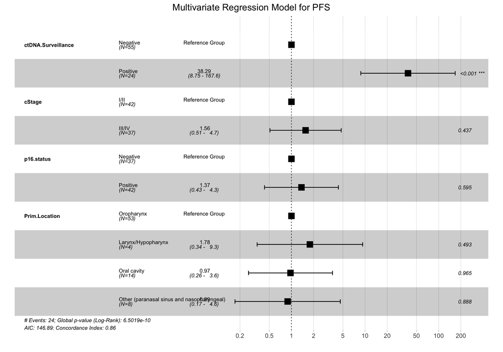

```r
# **Multivariate cox regression for PFS ctDNA status at surveillance**

rm(list=ls())
setwd("~/Downloads")
circ_data <- read.csv("CLIA HNSCC Peddada Clinical Data.csv")
circ_data <- circ_data[circ_data$ctDNA.available=="TRUE",]
circ_data <- circ_data[circ_data$ctDNA.Surveillance!="",]

circ_data$ctDNA.Surveillance <- factor(circ_data$ctDNA.Surveillance, levels=c("NEGATIVE","POSITIVE"), labels = c("Negative", "Positive"))
circ_data$cStage <- factor(circ_data$cStage, levels = c("I/II", "III/IV"))
circ_data$p16.status <- factor(circ_data$p16.status, levels = c("Negative", "Positive"))
circ_data$Prim.Location <- factor(circ_data$Prim.Location, levels = c("Oropharynx", "Larynx/Hypopharynx", "Oral cavity", "Other (paranasal sinus and nasopharyngeal)"))
surv_object <- Surv(time = circ_data$PFS.months, event = circ_data$PFS.Event)
cox_fit <- coxph(surv_object ~ ctDNA.Surveillance + cStage + p16.status + Prim.Location, data=circ_data)
ggforest(cox_fit, data = circ_data, main = "Multivariate Regression Model for PFS", refLabel = "Reference Group")
```

```r
test.ph <- cox.zph(cox_fit)
```

```r
# **ctDNA and MTM/mL Dynamics for pts at surveillance window**

# **Dynamics and MTM/mL plots for patients with ctDNA negative at surveillance**
rm(list=ls())
setwd("~/Downloads")
df <- read.csv("CLIA HNSCC ctDNA MTM.csv", stringsAsFactors = FALSE)
df <- df[df$ctDNA.Surveillance=="NEGATIVE",]

df$PFS.Event <- ifelse(df$PFS.Event %in% c("No", "no", "FALSE", "False", "0"), FALSE,
                       ifelse(df$PFS.Event %in% c("Yes", "yes", "TRUE", "True", "1"), TRUE, NA))
df$PFS.Event <- factor(df$PFS.Event, levels = c(FALSE, TRUE))
df <- df %>%
  group_by(PatientName) %>%
  filter(n() >= 2) %>% #keep only pts with at least 2 post-surgery time points
  ungroup()

num_unique <- length(unique(df$PatientName))
cat("Number of unique patients:", num_unique, "\n")
```

```
## Number of unique patients: 55
```

```r
df_patient_pfs <- df %>%
  group_by(PatientName) %>%
  dplyr::summarize(
    PFS_True = any(PFS.Event == TRUE, na.rm = TRUE),
    PFS_False = all(PFS.Event == FALSE, na.rm = TRUE)
  )

num_true <- sum(df_patient_pfs$PFS_True)
num_false <- sum(df_patient_pfs$PFS_False)

cat("Number of unique patients with Event:", num_true, "\n")
```

```
## Number of unique patients with Event: 2
```

```r
cat("Number of unique patients with No Event:", num_false, "\n")
```

```
## Number of unique patients with No Event: 53
```

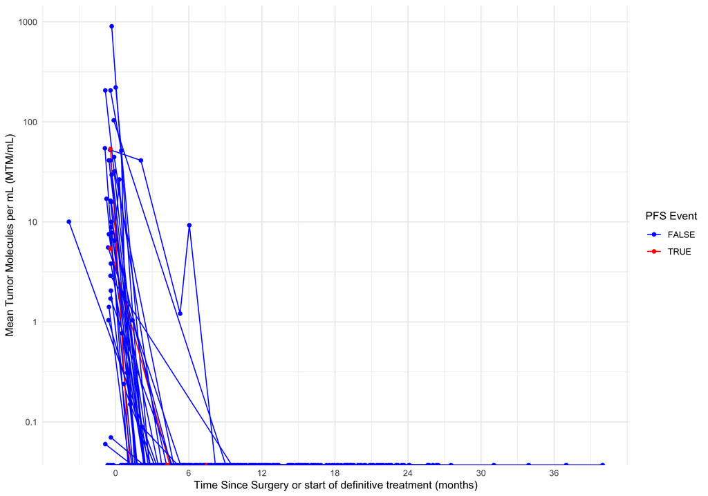

```r
p <- ggplot(df, aes(x = date.diff.months,
                    y = MTM.mL,
                    group = PatientName,
                    color = PFS.Event)) +
  geom_line() +      # Connect timepoints for each patient
  geom_point() +     # Add points for each timepoint
  # Use a log10 scale for the y-axis with specified breaks
  scale_y_log10(breaks = c(0.01, 0.1, 1, 10, 100, 1000),
                labels = c("0.01","0.1", "1", "10", "100", "1000")) +
  scale_x_continuous(breaks = seq(0, max(df$date.diff.months, na.rm = TRUE), by = 6)) +
  scale_color_manual(values = c("FALSE" = "blue", "TRUE" = "red")) +
  labs(
    x = "Time Since Surgery or start of definitive treatment (months)",
    y = "Mean Tumor Molecules per mL (MTM/mL)",
    color = "PFS Event"
  ) +
  theme_minimal()
print(p)
```

```r
# **Dynamics and MTM/mL plots for patients with ctDNA positive at surveillance**
rm(list=ls())
setwd("~/Downloads")
df <- read.csv("CLIA HNSCC ctDNA MTM.csv", stringsAsFactors = FALSE)
df <- df[df$ctDNA.Surveillance=="POSITIVE",]

df$PFS.Event <- ifelse(df$PFS.Event %in% c("No", "no", "FALSE", "False", "0"), FALSE,
                       ifelse(df$PFS.Event %in% c("Yes", "yes", "TRUE", "True", "1"), TRUE, NA))
df$PFS.Event <- factor(df$PFS.Event, levels = c(FALSE, TRUE))
df <- df %>%
  group_by(PatientName) %>%
  filter(n() >= 2) %>% #keep only pts with at least 2 post-surgery time points
  ungroup()

num_unique <- length(unique(df$PatientName))
cat("Number of unique patients:", num_unique, "\n")
```

```
## Number of unique patients: 23
```

```r
df_patient_pfs <- df %>%
  group_by(PatientName) %>%
  dplyr::summarize(
    PFS_True = any(PFS.Event == TRUE, na.rm = TRUE),
    PFS_False = all(PFS.Event == FALSE, na.rm = TRUE)
  )

num_true <- sum(df_patient_pfs$PFS_True)
num_false <- sum(df_patient_pfs$PFS_False)

cat("Number of unique patients with Event:", num_true, "\n")
```

```
## Number of unique patients with Event: 21
```

```r
cat("Number of unique patients with No Event:", num_false, "\n")
```

```
## Number of unique patients with No Event: 2
```

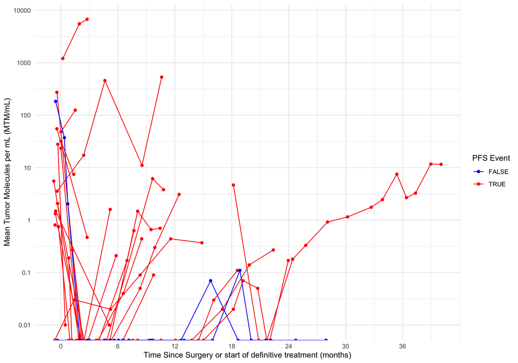

```r
p <- ggplot(df, aes(x = date.diff.months,
                    y = MTM.mL,
                    group = PatientName,
                    color = PFS.Event)) +
  geom_line() +      # Connect timepoints for each patient
  geom_point() +     # Add points for each timepoint
  # Use a log10 scale for the y-axis with specified breaks
  scale_y_log10(breaks = c(0.01, 0.1, 1, 10, 100, 1000, 10000),
                labels = c("0.01","0.1", "1", "10", "100", "1000", "10000")) +
  scale_x_continuous(breaks = seq(0, max(df$date.diff.months, na.rm = TRUE), by = 6)) +
  scale_color_manual(values = c("FALSE" = "blue", "TRUE" = "red")) +
  labs(
    x = "Time Since Surgery or start of definitive treatment (months)",
    y = "Mean Tumor Molecules per mL (MTM/mL)",
    color = "PFS Event"
  ) +
  theme_minimal()
print(p)
```

```r
# **Median numbers of time points in the longitudinal setting for pts with MRD & Surveillance time points available**

rm(list=ls())
setwd("~/Downloads")
circ_data <- read.csv("CLIA HNSCC Peddada Clinical Data.csv")
circ_data <- circ_data[circ_data$ctDNA.complete=="TRUE",]
circ_data <- circ_data[circ_data$ctDNA.Surveillance!="",]
circ_datadf <- as.data.frame(circ_data)

median_Nsurvtps <- median(circ_datadf$Nsurvtps, na.rm = TRUE)
min_Nsurvtps <- min(circ_datadf$Nsurvtps, na.rm = TRUE)
max_Nsurvtps <- max(circ_datadf$Nsurvtps, na.rm = TRUE)

cat(sprintf("Median # of surveillance time points: %d (%d-%d)\n",
            median_Nsurvtps, min_Nsurvtps, max_Nsurvtps))
```

```
## Median # of surveillance time points: 4 (1-20)
```

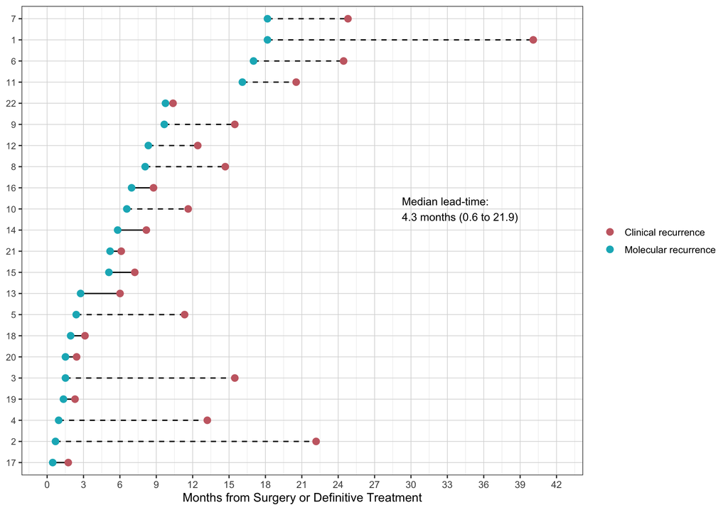

```r
# **Plot for individual lead-time calculations for each pt**

rm(list=ls())
csv_path <- "~/Downloads/CLIA HNSCC Peddada_Lead Time pts.csv"
df <- read.csv(csv_path, check.names = FALSE)
id_candidates <- c("Patient","ID","Pt","Subject","Sample")
id_col <- id_candidates[id_candidates %in% names(df)][1]
if (is.na(id_col)) {
  df <- df %>% mutate(Patient = row_number())
  id_col <- "Patient"
}

num_cols <- intersect(c("MR","CR","LT"), names(df))
df[num_cols] <- lapply(df[num_cols], function(x) suppressWarnings(as.numeric(x)))

# If LT missing, compute in days
if (!("LT" %in% names(df))) {
  df <- df %>% mutate(LT = CR - MR)
}

# ---- convert to months ----
# Approximate: 30.44 days per month (average)
days_to_months <- function(x) x / 30.437

df <- df %>%
  mutate(MR_mo = days_to_months(MR),
         CR_mo = days_to_months(CR),
         LT_mo = days_to_months(LT))

# ---- ordering for y-axis ----
df <- df %>%
  mutate(Earliest = pmin(MR_mo, CR_mo, na.rm = TRUE)) %>%
  arrange(Earliest) %>%
  mutate(Patient_f = factor(.data[[id_col]], levels = .data[[id_col]]))

# ---- long format for points ----
points_long <- df %>%
  select(Patient_f, MR_mo, CR_mo) %>%
  pivot_longer(c(MR_mo, CR_mo), names_to = "Type", values_to = "Months") %>%
  mutate(Type = dplyr::recode(Type,
                              "MR_mo" = "Molecular recurrence",
                              "CR_mo" = "Clinical recurrence"))

# ---- segments between MR and CR ----
segments_df <- df %>%
  transmute(Patient_f,
            x0 = MR_mo, x1 = CR_mo,
            lt_flag = if_else(LT > 120, "gt120", "le120"))

# ---- annotation ----
med_lt  <- median(df$LT_mo, na.rm = TRUE)
min_lt  <- min(df$LT_mo, na.rm = TRUE)
max_lt  <- max(df$LT_mo, na.rm = TRUE)

annot_label <- sprintf("Median lead-time:\n%.1f months (%.1f to %.1f)",
                       med_lt, min_lt, max_lt)

# ---- plot ----
pal <- c("Molecular recurrence" = "#10B4C1",
         "Clinical recurrence"  = "#C96A72")

x_max <- max(c(df$MR_mo, df$CR_mo), na.rm = TRUE)
y_mid <- levels(df$Patient_f)[ceiling(nlevels(df$Patient_f) * 0.55)]

p <- ggplot() +
  geom_segment(data = segments_df,
               aes(x = x0, xend = x1, y = Patient_f, yend = Patient_f,
                   linetype = lt_flag),
               linewidth = 0.6, color = "black") +
  scale_linetype_manual(values = c(le120 = "solid", gt120 = "dashed"),
                        guide = "none") +
  geom_point(data = points_long,
             aes(x = Months, y = Patient_f, color = Type),
             size = 2.8) +
  scale_color_manual(values = pal, name = NULL) +
  labs(x = "Months from Surgery or Definitive Treatment", y = NULL) +
  annotate("text",
           x = x_max * 0.73,
           y = y_mid,
           label = annot_label,
           hjust = 0, vjust = 0.5, size = 3.8) +
  scale_x_continuous(breaks = seq(0, ceiling(x_max/3)*3, by = 3)) +
  coord_cartesian(xlim = c(0, x_max * 1.05)) +
  theme_bw(base_size = 12) +
  theme(
    panel.grid.major = element_line(color = "grey85", linewidth = 0.3),
    panel.grid.minor = element_line(color = "grey92", linewidth = 0.2),
    axis.text.y = element_text(size = 9)
  )

print(p)
```

```r
wc_df <- df %>% dplyr::select(MR, CR) %>% tidyr::drop_na()
paired_diff <- wc_df$CR - wc_df$MR

wilx <- wilcox.test(
  x = wc_df$CR, y = wc_df$MR,
  paired = TRUE,
  alternative = "two.sided",
  conf.int = TRUE,      # gives CI for the Hodges–Lehmann estimate of the median difference
  exact = FALSE         # safer for ties/large N
)

W_stat   <- unname(wilx$statistic)          # Wilcoxon V
p_value  <- wilx$p.value
HL_est   <- unname(wilx$estimate)           # median of (CR - MR)
HL_ci    <- wilx$conf.int                   # CI for median difference

# Simple p-value formatter for annotation/publication
fmt_p <- function(p) {
  if (is.na(p)) return("NA")
  if (p < 0.001) "< 0.001" else sprintf("= %.3f", round(p, 3))
}
p_text <- paste0("P ", fmt_p(p_value))  # e.g., "P = 0.003" or "P < 0.001"

# Optional: print a compact summary
cat("\nPaired Wilcoxon signed-rank test (CR vs MR)\n",
    "-------------------------------------------\n",
    sprintf("N pairs: %d", nrow(wc_df)), "\n",
    sprintf("W (V): %g", W_stat), "\n",
    sprintf("P-value: %s", ifelse(p_value < 0.001, "< 0.001", sprintf("%.6f", p_value))), "\n",
    sprintf("Hodges–Lehmann median difference (CR - MR): %.1f days", HL_est), "\n",
    sprintf("95%% CI: [%.1f, %.1f] days", HL_ci[1], HL_ci[2]), "\n", sep = "")
```

```
##
## Paired Wilcoxon signed-rank test (CR vs MR)
## -------------------------------------------
## N pairs: 22
## W (V): 253
## P-value: < 0.001
## Hodges–Lehmann median difference (CR - MR): 145.5 days
## 95% CI: [86.5, 248.5] days
```

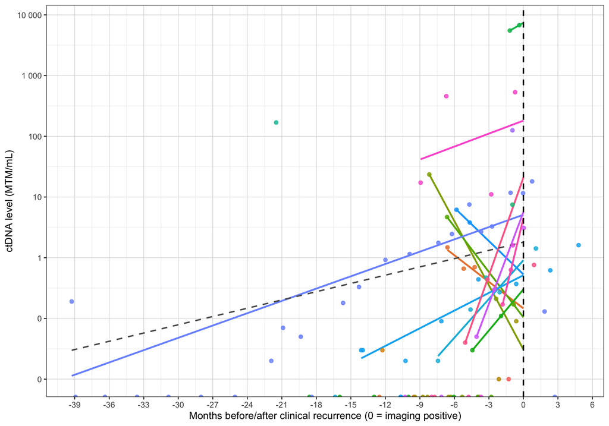

```r
# **ctDNA velocity and lead time liner regression**

csv_path <- "~/Downloads/CLIA HNSCC Peddada_ctDNA velocity.csv"  # <- adjust if needed
df_raw <- read.csv(csv_path, check.names = FALSE)
df <- df_raw %>%
  rename(MTM_mL = `MTM/mL`) %>%
  mutate(
    daysCR.months = as.numeric(daysCR.months),
    MTM_mL = as.numeric(MTM_mL)
  ) %>%
  filter(!is.na(PatientName), !is.na(daysCR.months), !is.na(MTM_mL))

preCR <- df %>%
  filter(daysCR.months <= 0, is.finite(MTM_mL), MTM_mL > 0)

eligible <- preCR %>%
  group_by(PatientName) %>%
  filter(n() >= 2, n_distinct(daysCR.months) >= 2) %>%
  ungroup()
if (nrow(eligible) == 0) {
  warning("No patients have ≥2 valid pre-recurrence points with distinct times; regression lines will be omitted.")
}

fits <- eligible %>%
  group_by(PatientName) %>%
  summarise(x_min = min(daysCR.months, na.rm = TRUE), .groups = "drop") %>%
  mutate(grid = map(x_min, ~seq(.x, 0, length.out = 50))) %>%
  select(PatientName, grid)

predict_patient <- function(dat, newx) {
  if (length(newx) == 0) {
    return(tibble(daysCR.months = numeric(0), MTM_mL = numeric(0)))
  }
  dat2 <- dat %>%
    filter(is.finite(MTM_mL), MTM_mL > 0) %>%
    mutate(log_ctdna = log10(MTM_mL))
  if (nrow(dat2) < 2 || n_distinct(dat2$daysCR.months) < 2 || any(!is.finite(dat2$log_ctdna))) {
    return(tibble(daysCR.months = numeric(0), MTM_mL = numeric(0)))
  }
  m <- lm(log_ctdna ~ daysCR.months, data = dat2)
  tibble(
    daysCR.months = newx,
    MTM_mL = 10 ^ predict(m, newdata = tibble(daysCR.months = newx))
  )
}

pred_lines <- eligible %>%
  group_by(PatientName) %>%
  tidyr::nest() %>%                       # list-column "data" per patient
  left_join(fits, by = "PatientName") %>% # list-column "grid" per patient
  mutate(pred = map2(data, grid, ~predict_patient(.x, .y))) %>%
  select(PatientName, pred) %>%
  tidyr::unnest(pred)

pooled_line <- {
  if (nrow(preCR) >= 2 && n_distinct(preCR$daysCR.months) >= 2) {
    pooled_x <- seq(min(preCR$daysCR.months, na.rm = TRUE), 0, length.out = 100)
    pooled_fit <- lm(log10(MTM_mL) ~ daysCR.months, data = preCR)
    tibble(
      daysCR.months = pooled_x,
      MTM_mL = 10 ^ predict(pooled_fit, newdata = tibble(daysCR.months = pooled_x))
    )
  } else {
    tibble(daysCR.months = numeric(0), MTM_mL = numeric(0))
  }
}

x_min <- floor(min(df$daysCR.months, na.rm = TRUE) / 3) * 3
x_max <- ceiling(max(df$daysCR.months, na.rm = TRUE) / 3) * 3
y_min_pos <- max(min(df$MTM_mL[df$MTM_mL > 0], na.rm = TRUE) / 2, 0.01)
y_max_pos <- 10 ^ ceiling(log10(max(df$MTM_mL, na.rm = TRUE)))
log_breaks <- 10 ^ seq(floor(log10(y_min_pos)), ceiling(log10(y_max_pos)))

p <- ggplot() +
  # per-patient fitted lines (if any)
  geom_line(data = pred_lines,
            aes(x = daysCR.months, y = MTM_mL, color = PatientName),
            linewidth = 1) +
  # pooled dashed trend (if any)
  geom_line(data = pooled_line,
            aes(x = daysCR.months, y = MTM_mL),
            linewidth = 0.8, linetype = "dashed", color = "grey35") +
  # raw points (all timepoints, before and after)
  geom_point(data = df,
             aes(x = daysCR.months, y = MTM_mL, color = PatientName),
             size = 1.8, alpha = 0.85) +
  # vertical line at imaging-positive date
  geom_vline(xintercept = 0, linetype = "dashed", linewidth = 0.8, color = "black") +
  scale_y_log10(breaks = log_breaks,
                labels = label_number(accuracy = 1)) +
  scale_x_continuous(breaks = seq(x_min, x_max, by = 3)) +  # every 3 months
  labs(
    x = "Months before/after clinical recurrence (0 = imaging positive)",
    y = "ctDNA level (MTM/mL)",
    color = "Patient"
  ) +
  theme_bw(base_size = 12) +
  theme(
    panel.grid.major = element_line(color = "grey85", linewidth = 0.3),
    panel.grid.minor = element_line(color = "grey92", linewidth = 0.2),
    legend.position = "none"  # change to "right" if you want the legend
  )

print(p)
```